Saltar al contenido principal

# Reto en clase. Clases 23 y 24

Series de tiempo univariadas, 3009297, 2026-II

Autor/a

Sarah Catalina Criollo García y Sara Jurado Giraldo

**Código en R**

```r
pareja <- "criollo-jurado"
f <- function(x, k = 2) formatC(as.numeric(x), format = "f", digits = k,
                               decimal.mark = ",")
meses <- c("enero", "febrero", "marzo", "abril", "mayo", "junio", "julio",
           "agosto", "septiembre", "octubre", "noviembre", "diciembre")

co2_datos <- read.csv("datos/co2-mauna-loa-mensual-2012-2025.csv")
viajeros_datos <- read.csv("datos/turistas-reino-unido-australia-trimestral.csv")
stopifnot(nrow(co2_datos) == 165, nrow(viajeros_datos) == 91,
          all(co2_datos$fecha == format(seq(as.Date("2012-01-01"),
                by = "month", length.out = 165), "%Y-%m")),
          all(is.finite(co2_datos$co2_ppm)), all(co2_datos$co2_ppm > 0))
z <- ts(co2_datos$co2_ppm, start = c(2012, 1), frequency = 12)
ztr <- window(z, end = c(2024, 9))
zva <- window(z, start = c(2024, 10))
viajeros <- ts(viajeros_datos$llegadas_miles, start = c(1990, 1), frequency = 4)
viajeros_entrenamiento <- window(viajeros, end = c(2010, 3))
viajeros_validacion <- window(viajeros, start = c(2010, 4))
stopifnot(length(ztr) == 153, length(zva) == 12,
          length(viajeros_entrenamiento) == 83, length(viajeros_validacion) == 8)
```

# Caso A: CO₂ de Mauna Loa

La serie $Z_t$ representa el promedio mensual de CO₂, medido en ppm, entre enero de 2012 y septiembre de 2025. Se reservan los últimos 12 meses para evaluar el pronóstico; el entrenamiento contiene 153 observaciones, de enero de 2012 a septiembre de 2024. La serie completa se utiliza para describir los datos en A1 y, después de la validación, para reestimar el modelo en A7.

## A1. Mirar la serie

**Código en R**

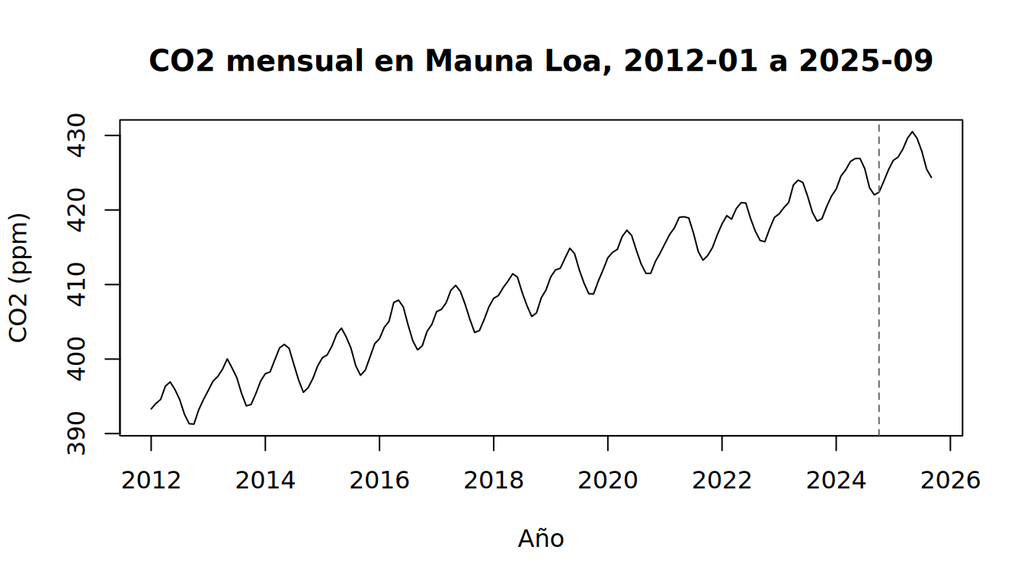

```r
plot(z, ylab = "CO2 (ppm)", xlab = "Año", main = "CO2 mensual en Mauna Loa, 2012-01 a 2025-09")
abline(v = 2024 + 9/12, lty = 2, col = "grey40")
```

**Código en R**

```r
d12 <- diff(z, 12)                        # crecimiento interanual mes a mes
crec_medio  <- mean(d12)
crec_ultimo <- mean(tail(d12, 12))        # oct-2024 a sep-2025 frente al año anterior

tend <- stats::filter(z, c(0.5, rep(1, 11), 0.5) / 12)   # media móvil 2x12
perfil_mes <- tapply(z - tend, cycle(z), mean, na.rm = TRUE)
mes_max <- which.max(perfil_mes); mes_min <- which.min(perfil_mes)
osc <- max(perfil_mes) - min(perfil_mes)

anios <- floor(time(z))
completos <- names(which(table(anios) == 12))
amp_anual <- tapply(z, anios, function(x) max(x) - min(x))[completos]
nivel_anual <- tapply(z, anios, mean)[completos]
cor_amp <- cor(amp_anual, nivel_anual)

round(perfil_mes, 2)
```

```
    1     2     3     4     5     6     7     8     9    10    11    12
 0.26  0.89  1.44  2.77  3.28  2.48  0.38 -1.91 -3.47 -3.39 -1.98 -0.73
```

**Código en R**

```r
rbind(nivel = round(nivel_anual, 1), amplitud = round(amp_anual, 2))
```

```
           2012  2013   2014   2015   2016   2017   2018   2019   2020   2021
nivel    394.10 396.7 398.80 401.00 404.40 406.80 408.70 411.60 414.20 416.40
amplitud   5.66   6.3   6.42   6.33   6.67   6.32   5.73   6.12   5.79   5.83
           2022  2023   2024
nivel    418.50 421.1 424.60
amplitud   5.23   5.5   4.88
```

**Código en R**

```r
c(crec_medio = crec_medio, crec_ultimo = crec_ultimo, oscilacion = osc, cor_amp_nivel = cor_amp)
```

```
   crec_medio   crec_ultimo    oscilacion cor_amp_nivel
    2.5642484     3.0200000     6.7464343    -0.6999171
```

**Código en R**

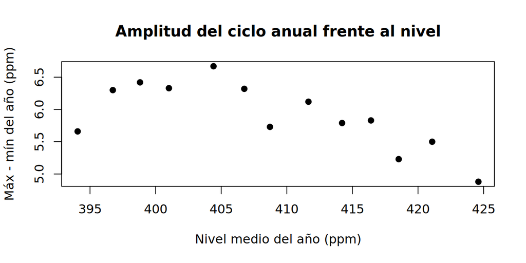

```r
plot(as.numeric(nivel_anual), as.numeric(amp_anual), pch = 19,
     xlab = "Nivel medio del año (ppm)", ylab = "Máx - mín del año (ppm)",
     main = "Amplitud del ciclo anual frente al nivel")
```

**Respuesta.** La concentración aumenta en promedio 2,564 ppm por año y en los últimos doce meses aumentó 3,020 ppm en promedio respecto al año anterior. Calculamos el crecimiento como el promedio de $Z_t-Z_{t-12}$ y quitamos la tendencia con una media móvil centrada:

$$\widehat T_t=\frac{1}{12}\left(\frac{Z_{t-6}}2+\sum_{j=-5}^{5}Z_{t+j}+\frac{Z_{t+6}}2\right).$$

El ciclo alcanza su máximo en mayo y su mínimo en septiembre, con una oscilación de 6,746 ppm. La amplitud de los años completos está entre 4,88 y 6,67 ppm y su correlación con el nivel es -0,700. Como no aumenta con el nivel, preferimos un ciclo aditivo.

## A2. ¿Hace falta transformar?

**Código en R**

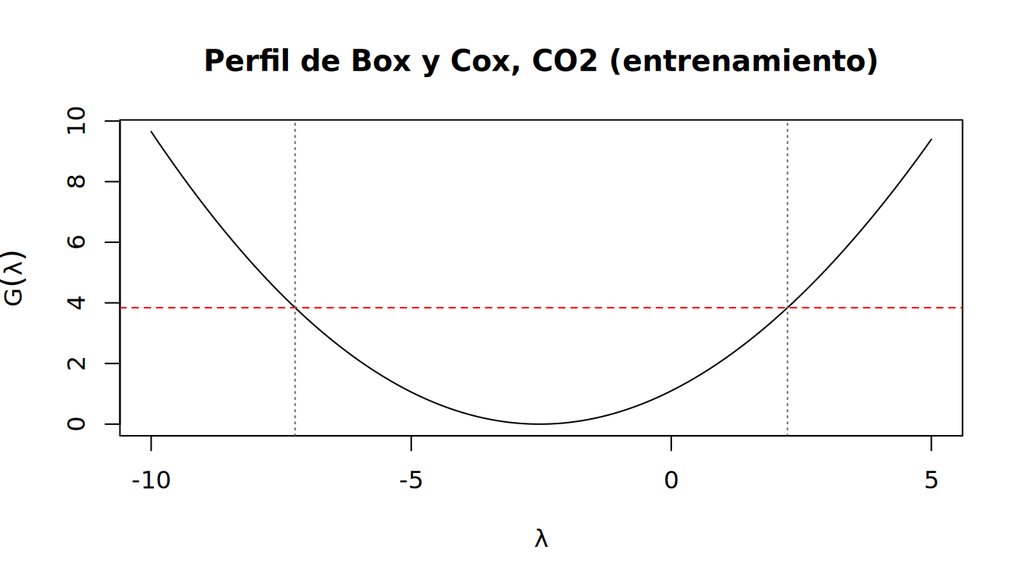

```r
# Perfil de Box-Cox con un AR(4).
bc <- function(x, lambda) {
  g <- exp(mean(log(x)))
  # Se centra en la media geométrica; la constante desaparece al diferenciar.
  if (lambda == 0) {
    g * log(x/g)
  } else {
    g * expm1(lambda * log(x/g)) / lambda
  }
}
perfil_bc <- function(x, s, malla = round(seq(-1, 2, by = 0.01), 2)) {
  S <- sapply(malla, function(lambda) {
    w <- diff(diff(as.numeric(bc(x, lambda)), lag = s))
    X <- embed(w, 5)
    sum(residuals(lm(X[, 1] ~ X[, -1]))^2)
  })
  data.frame(lambda = malla, S = S,
             G = (length(x) - s - 5) * log(S / min(S)))
}

pA_inicial <- perfil_bc(ztr, 12)
# El mínimo está en el borde de la malla inicial; ampliamos el rango.
pA <- perfil_bc(ztr, 12, round(seq(-10, 5, by = 0.01), 2))
i <- which.min(pA$G)
lam_hat <- pA$lambda[i]
critico <- qchisq(.95, 1)
# Interpolación lineal en los dos cruces con el valor crítico.
izq <- max(which(pA$G > critico & seq_len(nrow(pA)) < i))
der <- min(which(pA$G > critico & seq_len(nrow(pA)) > i))
compat <- c(approx(pA$G[c(izq,izq+1)],pA$lambda[c(izq,izq+1)],critico)$y,
            approx(pA$G[c(der-1,der)],pA$lambda[c(der-1,der)],critico)$y)
G_en <- function(l) pA$G[which.min(abs(pA$lambda - l))]
plot(pA$lambda, pA$G, type = "l", xlab = expression(lambda), ylab = expression(G(lambda)),
     main = "Perfil de Box y Cox, CO2 (entrenamiento)")
abline(h = critico, lty = 2, col = "red")
abline(v = compat, lty = 3, col = "grey40")
```

**Código en R**

```r
rel <- max(ztr) / min(ztr)
c(lambda_malla_inicial = pA_inicial$lambda[which.min(pA_inicial$G)],
  lambda_hat = lam_hat, lim_inf = compat[1], lim_sup = compat[2],
  G1 = G_en(1), G0.5 = G_en(0.5), G0 = G_en(0), max_sobre_min = rel)
```

```
lambda_malla_inicial           lambda_hat              lim_inf
           -1.000000            -2.530000            -7.232070
             lim_sup                   G1                 G0.5
            2.234343             2.125784             1.570965
                  G0        max_sobre_min
            1.098483             1.091088
```

**Respuesta.** Usamos la transformación de Box-Cox normalizada con la media geométrica $g=\exp(n^{-1}\sum_{t=1}^{n}\log Z_t)$:

$$Z_t^{(\lambda)}=\begin{cases}\dfrac{Z_t^\lambda-1}{\lambda g^{\lambda-1}},&\lambda\ne0,\\g\log Z_t,&\lambda=0.\end{cases}$$

Con $W_t^{(\lambda)}=\nabla\nabla_{12}Z_t^{(\lambda)}$ ajustamos un AR(4) con constante y calculamos el perfil a partir de la suma de cuadrados de sus residuos $S(\lambda)$:

$$W_t^{(\lambda)}=c+\sum_{i=1}^{4}\phi_iW_{t-i}^{(\lambda)}+a_t,\qquad G(\lambda)=n^*\log\frac{S(\lambda)}{S(\widehat\lambda)},\quad n^*=153-12-5=136.$$

Ampliamos la malla porque el mínimo inicial estaba en un extremo, y obtuvimos $\widehat\lambda=$ -2,53 y un intervalo de compatibilidad del 95 % de [-7,23; 2,23] usando el valor crítico $\chi^2_{1;0,95}=3,841$. En particular, $G(1)=$ 2,126, $G(0,5)=$ 1,571 y $G(0)=$ 1,098 son menores que 3,841. El máximo supera al mínimo del entrenamiento en solo 9,11 %, lo que ayuda a explicar por qué varias transformaciones son compatibles con los datos. Como $\lambda=1$ pertenece al intervalo y en A1 no vimos un aumento de la amplitud con el nivel, decidimos no transformar la serie.

## A3. ¿Cuántas diferencias?

**Código en R**

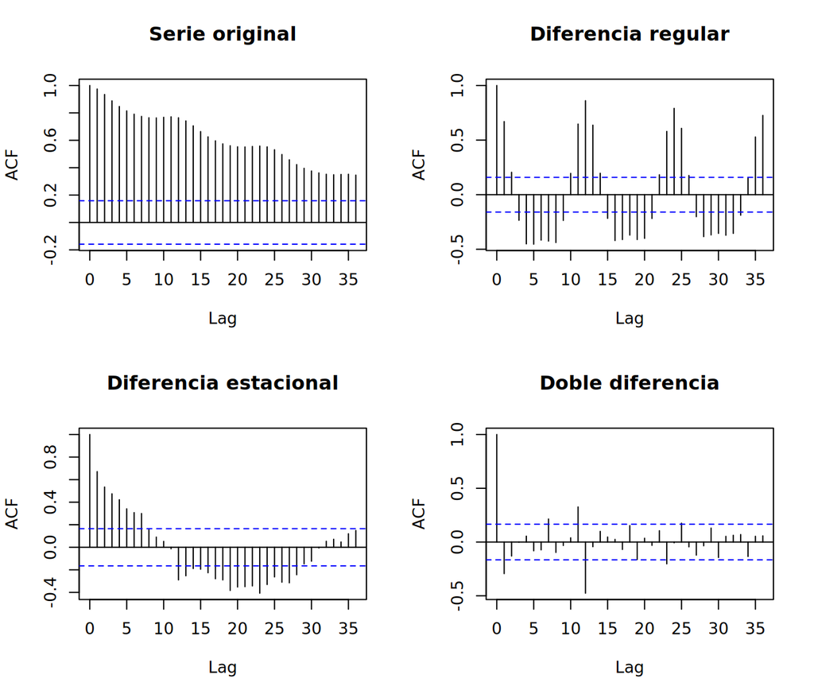

```r
par(mfrow = c(2, 2))
acf(as.numeric(ztr), lag.max = 36, main = "Serie original")
acf(as.numeric(diff(ztr)), lag.max = 36, main = "Diferencia regular")
acf(as.numeric(diff(ztr, 12)), lag.max = 36, main = "Diferencia estacional")
acf(as.numeric(diff(diff(ztr, 12))), lag.max = 36, main = "Doble diferencia")
```

**Código en R**

```r
par(mfrow = c(1, 1))
r1  <- acf(diff(ztr), lag.max = 36, plot = FALSE)$acf[-1]
r12 <- acf(diff(ztr, 12), lag.max = 12, plot = FALSE)$acf[-1]
list(acf_nabla_12_24_36 = round(r1[c(12, 24, 36)], 3),
     acf_nabla12_1a6 = round(r12[1:6], 3))
```

```
$acf_nabla_12_24_36
[1] 0.861 0.790 0.726

$acf_nabla12_1a6
[1] 0.671 0.534 0.474 0.422 0.341 0.307
```

**Respuesta.** Después de aplicar la diferencia regular $\nabla Z_t=Z_t-Z_{t-1}$, las autocorrelaciones en los rezagos 12, 24 y 36 son 0,861; 0,790; 0,726. Como siguen siendo altas y disminuyen lentamente, tomamos $D=1$. Al aplicar solamente la diferencia estacional $\nabla_{12}Z_t=Z_t-Z_{t-12}$, las autocorrelaciones en los rezagos 1 a 6 son 0,671; 0,534; 0,474; 0,422; 0,341; 0,307, por lo que también necesitamos $d=1$. Trabajamos entonces con la doble diferencia

$$W_t=(1-B)(1-B^{12})Z_t=Z_t-Z_{t-1}-Z_{t-12}+Z_{t-13}.$$

La ACF de $W_t$ ya no muestra los descensos lentos de las otras gráficas y quedan 140 observaciones para identificar el modelo. Como $d+D=2$, no incluimos constante.

## Bono. Raíces unitarias estacionales (HEGY)

**Código en R**

```r
# Prueba sobre el entrenamiento: constante y 11 indicadores mensuales.
# Comparamos la especificación sin tendencia y con tendencia lineal.
# Los rezagos se seleccionan por BIC hasta 12.
h_sin <- tryCatch(uroot::hegy.test(ztr, deterministic = c(1, 0, 1),
                     lag.method = "BIC", maxlag = 12, pvalue = "RS"),
                  error = function(e) e)
h_con <- tryCatch(uroot::hegy.test(ztr, deterministic = c(1, 1, 1),
                     lag.method = "BIC", maxlag = 12, pvalue = "RS"),
                  error = function(e) e)
hegy_ok <- !inherits(h_sin, "error") && !inherits(h_con, "error")
hegy_estacional <- FALSE
if (hegy_ok) {
  # Estadísticos y valores p para cada frecuencia.
  pruebas <- names(h_sin$statistics)
  hegy_tab <- data.frame(
    prueba = pruebas,
    sin_tendencia = as.numeric(h_sin$statistics[pruebas]),
    p_sin = as.numeric(h_sin$pvalues[pruebas]),
    con_tendencia = as.numeric(h_con$statistics[pruebas]),
    p_con = as.numeric(h_con$pvalues[pruebas]))
  print(knitr::kable(hegy_tab, digits = 4, row.names = FALSE,
           caption = "HEGY: estadísticos y valores p (entrenamiento)"))
  cat("\nRezagos elegidos: ", h_sin$lag.order, " sin tendencia y ",
      h_con$lag.order, " con tendencia.\n\n", sep = "")
  # t_2: frecuencia pi; F por cada par de frecuencias complejas.
  est <- c("t_2", "F_3:4", "F_5:6", "F_7:8", "F_9:10", "F_11:12")
  ps <- h_sin$pvalues[est]; pc <- h_con$pvalues[est]
  hegy_estacional <- all(is.finite(c(ps, pc))) && all(c(ps, pc) < .05)
} else {
  cat("No fue posible ejecutar HEGY. Revisar la instalación de uroot.\n\n")
  if (inherits(h_sin, "error")) cat(conditionMessage(h_sin), "\n\n")
  if (inherits(h_con, "error")) cat(conditionMessage(h_con), "\n\n")
}
```

HEGY: estadísticos y valores p (entrenamiento)

| prueba | sin_tendencia | p_sin | con_tendencia | p_con |
| --- | --- | --- | --- | --- |
| t_1 | 0.7528 | 0.9918 | -2.6253 | 0.1893 |
| t_2 | -3.4680 | 0.0073 | -3.5761 | 0.0059 |
| F_3:4 | 13.3985 | 0.0004 | 15.9868 | 0.0000 |
| F_5:6 | 9.7730 | 0.0051 | 10.8170 | 0.0027 |
| F_7:8 | 13.4973 | 0.0004 | 15.1118 | 0.0001 |
| F_9:10 | 18.0515 | 0.0000 | 19.2270 | 0.0000 |
| F_11:12 | 9.3008 | 0.0071 | 9.8488 | 0.0052 |
| F_2:12 | 29.8866 | 0.0000 | 32.0330 | 0.0000 |
| F_1:12 | 27.8701 | 0.0000 | 29.3875 | 0.0000 |

Rezagos elegidos: 0 sin tendencia y 0 con tendencia.

La prueba HEGY separa la raíz regular de las raíces en las frecuencias estacionales. Para una serie mensual, la regresión aumentada descompone la diferencia $\nabla_{12}Z_t$ en doce regresores asociados a esas frecuencias, términos deterministas y rezagos de la diferencia. Usamos constante e indicadores mensuales en ambas versiones; la segunda también incluye tendencia lineal.

**Prueba de la raíz regular ($t_1$)**

1. $H_0:\pi_1=0$ (raíz unitaria en $B=1$); $H_1:\pi_1<0$.
2. $t_1=\widehat\pi_1/\operatorname{ee}(\widehat\pi_1)$, con distribución no estándar de tipo Dickey-Fuller; no se usa una t de Student ni sus grados de libertad para obtener el valor p.
3. Rechazamos $H_0$ si el valor p de HEGY es menor que 0,05.
4. Sin tendencia: t1 = 0,753, p = 0,9918; con tendencia: t1 = -2,625, p = 0,1893.
5. Sin tendencia: no rechazamos; con tendencia: no rechazamos la hipótesis nula.
6. No encontramos evidencia suficiente para descartar una raíz regular; esto apoya d = 1.

**Raíces estacionales.** $t_2$ contrasta la raíz en la frecuencia $\pi$ y cada $F_{j:j+1}$ contrasta conjuntamente el par de raíces complejas correspondiente; $F_{2:12}$ contrasta todas las raíces estacionales en conjunto. Para cada contraste rechazamos al 5 % si su valor p es menor que 0,05, usando las distribuciones de HEGY. Sin tendencia, las frecuencias en las que no rechazamos son: ninguna; con tendencia: ninguna (un valor p faltante no permite decidir). Rechazamos las raíces unitarias en todas las frecuencias estacionales en ambas versiones. Esto favorece un ciclo anual estable, pero no demuestra que sea perfectamente fijo. HEGY no determina por sí sola la multiplicidad de la raíz en frecuencia cero. Aun así, el modelo de aerolínea con $D=1$ es una aproximación útil si $\Theta$ está cerca de uno, porque el factor $1-\Theta B^{12}$ casi cancela $1-B^{12}$ y permite representar un ciclo que cambia lentamente; comprobamos este argumento en A5 y su utilidad predictiva en A6.

*Referencia metodológica del bono:* documentación de [`uroot::hegy.test`](https://search.r-project.org/CRAN/refmans/uroot/help/hegy.test.html), que implementa la versión para periodicidad mensual. La guía remite a Castaño (pp. 72–75), Franses (1990) y Beaulieu y Miron (1993); no contamos con las notas específicas de Castaño para contrastar el procedimiento.

## A4. Identificar el modelo

**Código en R**

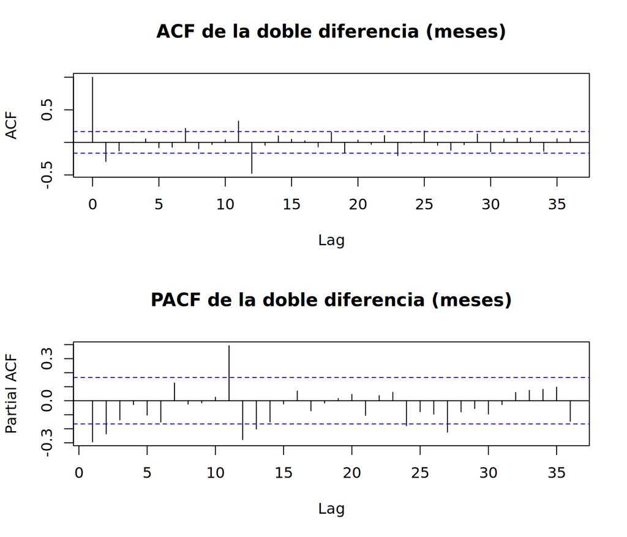

```r
W <- diff(diff(ztr, lag = 12))
nW <- length(W)
banda <- 1.96 / sqrt(nW)
par(mfrow = c(2, 1))
acf(as.numeric(W), lag.max = 36, main = "ACF de la doble diferencia (meses)")
pacf(as.numeric(W), lag.max = 36, main = "PACF de la doble diferencia (meses)")
```

**Código en R**

```r
par(mfrow = c(1, 1))
rW <- as.numeric(acf(W, lag.max = 36, plot = FALSE)$acf)[-1]
pW <- as.numeric(pacf(W, lag.max = 36, plot = FALSE)$acf)
fuera <- data.frame(rezago = 1:36, ACF = rW, PACF = pW)
knitr::kable(fuera[abs(rW) > banda | abs(pW) > banda, ],
             digits = 3, row.names = FALSE,
             caption = "Rezagos fuera de la banda nominal de 95 %")
```

Rezagos fuera de la banda nominal de 95 %

| rezago | ACF | PACF |
| --- | --- | --- |
| 1 | -0.294 | -0.294 |
| 2 | -0.130 | -0.237 |
| 7 | 0.214 | 0.126 |
| 11 | 0.326 | 0.392 |
| 12 | -0.475 | -0.278 |
| 13 | -0.043 | -0.202 |
| 23 | -0.203 | 0.060 |
| 24 | -0.007 | -0.178 |
| 25 | 0.176 | -0.078 |
| 27 | -0.121 | -0.224 |

**Código en R**

```r
# Comparación de candidatos sobre la misma muestra de residuos.
criterios_css <- function(w, candidatos, s) {
  nc <- max(candidatos[, 1] + s * candidatos[, 3])
  tabla <- lapply(seq_len(nrow(candidatos)), function(i) {
    o <- candidatos[i, ]  # p, q, P, Q
    ajuste <- arima(as.numeric(w), order = c(o[1], 0, o[2]),
                    seasonal = list(order = c(o[3], 0, o[4]), period = s),
                    include.mean = FALSE, method = "CSS", n.cond = nc)
    e <- residuals(ajuste)[seq.int(nc + 1L, length(w))]
    N <- length(e); M <- sum(o)
    data.frame(p = o[1], q = o[2], P = o[3], Q = o[4], N = N, M = M,
               AIC = N * log(mean(e^2)) + 2 * M,
               SBC = N * log(mean(e^2)) + M * log(N), codigo = ajuste$code)
  })
  tabla <- do.call(rbind, tabla)
  tabla <- tabla[order(tabla$SBC), ]
  tabla$dSBC <- tabla$SBC - min(tabla$SBC)
  rownames(tabla) <- NULL
  tabla
}

# Candidatos de órdenes bajos sugeridos por los correlogramas.
# Se añade el candidato con AR y MA estacionales para comprobar el patrón mixto.
candidatos <- rbind(c(0,1,0,1), c(1,0,0,1), c(0,1,1,0),
                    c(1,1,0,1), c(0,2,0,1), c(0,1,0,2), c(0,1,1,1))
tabla_bic <- criterios_css(W, candidatos, 12)
knitr::kable(tabla_bic, digits = 3, caption = "Criterios condicionales con muestra común")
```

Criterios condicionales con muestra común

| p | q | P | Q | N | M | AIC | SBC | codigo | dSBC |
| --- | --- | --- | --- | --- | --- | --- | --- | --- | --- |
| 0 | 1 | 0 | 1 | 128 | 2 | -228.463 | -222.759 | 0 | 0.000 |
| 0 | 1 | 1 | 1 | 128 | 3 | -229.813 | -221.256 | 0 | 1.502 |
| 1 | 1 | 0 | 1 | 128 | 3 | -228.563 | -220.007 | 0 | 2.752 |
| 0 | 2 | 0 | 1 | 128 | 3 | -228.457 | -219.901 | 0 | 2.858 |
| 0 | 1 | 0 | 2 | 128 | 3 | -226.499 | -217.943 | 0 | 4.816 |
| 1 | 0 | 0 | 1 | 128 | 2 | -218.933 | -213.229 | 0 | 9.530 |
| 0 | 1 | 1 | 0 | 128 | 2 | -216.227 | -210.523 | 0 | 12.236 |

**Código en R**

```r
modelo_txt <- function(o) sprintf("(%d,1,%d)(%d,1,%d)12", o[1],o[2],o[3],o[4])
fila_a <- which(tabla_bic$p == 0 & tabla_bic$q == 1 &
                tabla_bic$P == 0 & tabla_bic$Q == 1)
orden_A <- list(order = c(0,1,1), seasonal = c(0,1,1))
# Si la ejecución contradice esta selección, revisar antes de entregar.
if (tabla_bic$dSBC[fila_a] >= 2 || any(tabla_bic$codigo != 0))
  stop("Revisar selección A4 o convergencia CSS antes de continuar")
```

**Respuesta.** En la parte regular, la ACF en 1 y 2 es -0,294 y -0,130, y la PACF es -0,294 y -0,237, lo que sugiere un MA(1). En los rezagos estacionales 12, 24 y 36, la ACF es -0,475; -0,007; 0,058, y la PACF en 12 y 24 es -0,278; -0,178, por lo que consideramos un MA(1) estacional. Los satélites teóricos del producto MA son 11 y 13 ($\rho_{11}=\rho_{13}=\rho_1\rho_{12}$), aunque en la muestra la ACF vale 0,326 y -0,043 y la PACF 0,392 y -0,202. También aparecen picos aislados de la ACF en 7, 23 y 25 (0,214; -0,203; 0,176) y de la PACF en 27 (-0,224), pero no vemos un patrón que justifique por sí solo más parámetros. Comparamos los candidatos mediante $SBC=N\log(\widehat\sigma_a^2)+M\log N$, sobre los mismos 128 residuos. Elegimos el modelo de aerolínea $(0,1,1)(0,1,1)_{12}$, con SBC de -222,759, porque el segundo, $(0,1,1)(1,1,1)_{12}$, queda a solo 1,502 unidades y requiere un parámetro más.

## A5. Estimar, validar y buscar atípicos

**Código en R**

```r
fitA <- arima(ztr, order = orden_A$order,
              seasonal = list(order = orden_A$seasonal, period = 12),
              include.mean = FALSE, method = "ML")
stopifnot(fitA$code == 0)
seA <- sqrt(diag(fitA$var.coef))
theta <- -coef(fitA)["ma1"]; Theta <- -coef(fitA)["sma1"]
tA <- -coef(fitA) / seA
knitr::kable(rbind(estimacion = -coef(fitA), ee = seA, t = tA), digits = 3,
             caption = "Coeficientes en la convención del curso")
```

Coeficientes en la convención del curso

|  | ma1 | sma1 |
| --- | --- | --- |
| estimacion | 0.486 | 0.816 |
| ee | 0.086 | 0.087 |
| t | 5.634 | 9.402 |

**Código en R**

```r
# Raíces de los factores MA: módulos > 1 equivalen a invertibilidad.
raiz_regular <- 1/abs(theta)
raiz_estacional <- (1/abs(Theta))^(1/12)
c(raiz_regular = unname(raiz_regular), raiz_estacional = unname(raiz_estacional),
  sigma2 = fitA$sigma2)
```

```
   raiz_regular raiz_estacional          sigma2
       2.058297        1.017081        0.135328
```

**Código en R**

```r
# Quitamos los primeros d + sD residuos por la inicialización.
e <- as.numeric(residuals(fitA))[-seq_len(13)]
Nres <- length(e); K <- 24; mA <- 2
lb <- Box.test(e, lag = K, type = "Ljung-Box", fitdf = mA)
print(lb)
```

```
    Box-Ljung test

data:  e
X-squared = 22.046, df = 22, p-value = 0.4572
```

**Código en R**

```r
# Asimetría, curtosis y estadístico de Jarque-Bera.
u <- e - mean(e)
S <- mean(u^3) / mean(u^2)^(3/2)
C <- mean(u^4) / mean(u^2)^2
zS <- S / sqrt(6/Nres); zC <- (C-3) / sqrt(24/Nres)
JB <- zS^2 + zC^2
pJB <- pchisq(JB, df = 2, lower.tail = FALSE)
round(c(n = Nres, asimetria = S, curtosis = C, zS = zS, zC = zC,
        JB = JB, p_JB = pJB), 3)
```

```
        n asimetria  curtosis        zS        zC        JB      p_JB
  140.000    -0.145     3.163    -0.701     0.393     0.646     0.724
```

**Código en R**

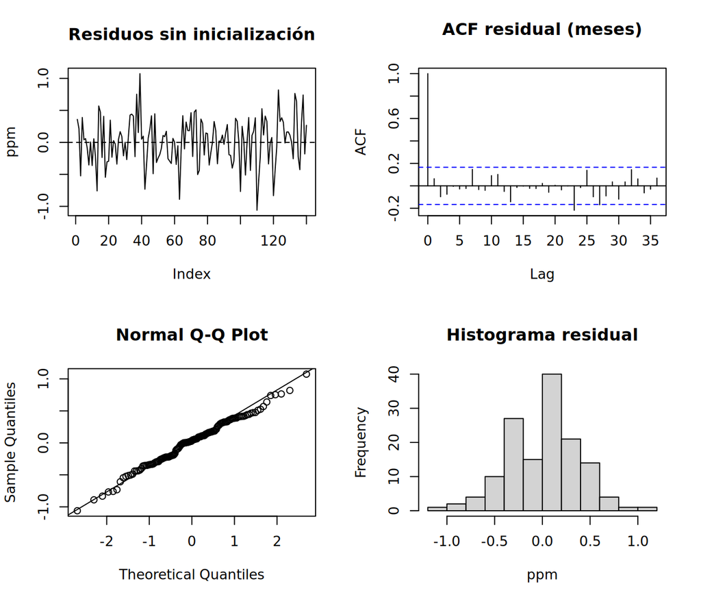

```r
par(mfrow = c(2,2))
plot(e, type = "l", main = "Residuos sin inicialización", ylab = "ppm"); abline(h=0,lty=2)
acf(e, lag.max = 36, main = "ACF residual (meses)")
qqnorm(e); qqline(e)
hist(e, main = "Histograma residual", xlab = "ppm")
```

**Código en R**

```r
par(mfrow = c(1,1))
```

**Código en R**

```r
# Pesos pi del modelo: a_t = pi(B) Z_t
pi_pesos <- function(fit, n) {
  cf <- coef(fit); a <- fit$arma; s <- a[5]
  get <- function(pref, k) if (k > 0) cf[paste0(pref, seq_len(k))] else numeric(0)
  mul <- function(x, y) {
    r <- numeric(length(x) + length(y) - 1)
    for (i in seq_along(x)) r[i:(i + length(y) - 1)] <- r[i:(i + length(y) - 1)] + x[i] * y
    r
  }
  est <- function(c) {
    if (length(c) == 0) return(1)
    v <- numeric(length(c) * s + 1)
    v[1] <- 1
    v[seq_along(c) * s + 1] <- c
    v
  }
  num <- mul(c(1, -get("ar", a[1])), est(-get("sar", a[3])))
  for (i in seq_len(a[6])) num <- mul(num, c(1, -1))
  for (i in seq_len(a[7])) num <- mul(num, c(1, rep(0, s - 1), -1))
  den <- mul(c(1, get("ma", a[2])), est(get("sma", a[4])))
  num <- c(num, numeric(max(0, n - length(num))))
  den <- c(den, numeric(max(0, n - length(den))))
  p <- numeric(n)
  for (j in 1:n) p[j] <- num[j] - if (j > 1) sum(den[2:j] * p[(j - 1):1]) else 0
  p
}

# Detección provisional de atípicos mediante filtros de intervención.
# Falta contrastar el procedimiento con el material específico de atípicos.
atipicos <- function(fit, delta = 0.7) {
  a <- as.numeric(residuals(fit)); n <- length(a)
  k0 <- fit$arma[6] + fit$arma[5] * fit$arma[7]
  ae <- a[seq.int(k0 + 1L, n)]
  sig <- 1.483 * median(abs(ae - median(ae)))
  p <- pi_pesos(fit, n)
  x_ls <- cumsum(p)
  x_tc <- as.numeric(stats::filter(p, delta, method = "recursive"))
  out <- lapply((k0 + 1):n, function(T) {
    m <- n - T + 1; aa <- a[T:n]
    lam <- function(x) {
      x <- x[1:m]
      sum(x * aa) / (sqrt(sum(x^2)) * sig)
    }
    data.frame(T = T, IO = a[T] / sig, AO = lam(p), LS = lam(x_ls), TC = lam(x_tc))
  })
  do.call(rbind, out)
}

# Calculamos los estadísticos para los cuatro tipos de atípicos.
atA <- atipicos(fitA)
maxA <- apply(abs(atA[, -1]), 2, max)
knitr::kable(data.frame(tipo = names(maxA), max_abs = as.numeric(maxA)), digits=3)
```

| tipo | max_abs |
| --- | --- |
| IO | 2.672 |
| AO | 2.832 |
| LS | 3.154 |
| TC | 3.315 |

**Código en R**

```r
alertas <- atA[apply(abs(atA[, -1]), 1, max) > 3.5, ]
alertas
```

```
[1] T  IO AO LS TC
<0 rows> (or 0-length row.names)
```

**Código en R**

```r
sobre <- rbind(c(1,1,0,1), c(0,2,0,1), c(0,1,1,1), c(0,1,0,2))
tab_sobre <- do.call(rbind,lapply(seq_len(nrow(sobre)), function(i) {
  o <- sobre[i, ]
  ajuste <- arima(ztr, order = c(o[1],1,o[2]),
                  seasonal = list(order=c(o[3],1,o[4]),period=12),
                  include.mean = FALSE,method="ML")
  nuevo <- setdiff(names(coef(ajuste)),names(coef(fitA)))
  signo <- if (grepl("^(ma|sma)",nuevo)) -1 else 1
  est <- signo * coef(ajuste)[nuevo]
  ee <- sqrt(ajuste$var.coef[nuevo,nuevo])
  data.frame(modelo=modelo_txt(o), parametro=nuevo, estimacion=unname(est),
             t=unname(est/ee), codigo=ajuste$code)
}))
knitr::kable(tab_sobre,digits=3,caption="Sobreajuste: un parámetro adicional por vez")
```

Sobreajuste: un parámetro adicional por vez

| modelo | parametro | estimacion | t | codigo |
| --- | --- | --- | --- | --- |
| (1,1,1)(0,1,1)12 | ar1 | 0.225 | 1.516 | 0 |
| (0,1,2)(0,1,1)12 | ma2 | 0.122 | 1.530 | 0 |
| (0,1,1)(1,1,1)12 | sar1 | -0.038 | -0.311 | 0 |
| (0,1,1)(0,1,2)12 | sma2 | -0.033 | -0.321 | 0 |

**Código en R**

```r
ic_Theta <- Theta + c(-1,1)*qnorm(0.975)*seA["sma1"]
round(ic_Theta,3)
```

```
[1] 0.646 0.986
```

**Respuesta.** El modelo estimado, con los signos MA de la notación del enunciado, es

$$\nabla\nabla_{12}Z_t=(1-0,486B)(1-0,816B^{12})a_t,\quad \widehat\sigma_a^2=0,1353,\quad a_t\sim WN(0,\sigma_a^2).$$

Los estadísticos $t$ de $\theta$ y $\Theta$ son 5,634 y 9,402, ambos mayores que 2 en valor absoluto; los módulos de las raíces MA son 2,058 y 1,017, por lo que el modelo es invertible.

**Ljung y Box (24 rezagos):**

1. $H_0:\rho_1=\cdots=\rho_{24}=0$; $H_1:$ al menos una de estas autocorrelaciones es distinta de cero.
2. $Q_{LB}=N'(N'+2)\sum_{k=1}^{24}\widehat r_k^2/(N'-k)\overset{aprox.}{\sim}\chi^2_{22}$ bajo $H_0$, con $N'=$ 140 residuos y dos parámetros MA estimados.
3. Se rechaza $H_0$ si $Q_{LB}>33,924$.
4. $Q_{LB}=$ 22,046; valor p = 0,4572.
5. Al 5 %, no se rechaza $H_0$.
6. No hay evidencia suficiente de autocorrelación residual hasta 24 meses.

La asimetría es -0,145, la curtosis es 3,163 y el estadístico $JB=$ 0,646 tiene un valor p de 0,724; junto con el gráfico Q-Q, esto no da evidencia suficiente para rechazar la normalidad. Con $\delta=0,7$, la escala $1,483\,MAD$ y el umbral 3,5, el mayor estadístico absoluto de atípicos es 3,315 y no encontramos observaciones que superen el umbral en la búsqueda realizada; falta contrastar este procedimiento con el material específico indicado en la guía. Al agregar por separado un parámetro AR o MA regular o estacional, el mayor valor absoluto de $t$ es 1,530, por lo que no vemos evidencia para añadirlos. El intervalo de Wald del 95 % para $\Theta$ es [0,646; 0,986], no contiene el 1 y, como la estimación está cerca de ese valor, el patrón estacional parece cambiar lentamente de un año a otro en lugar de ser exactamente fijo. Esto es compatible con un ciclo relativamente estable, como sugiere HEGY, aunque el intervalo no contiene uno y las pruebas no contrastan la misma hipótesis.

## A6. ¿Le gana el SARIMA a las referencias?

**Código en R**

```r
# Métricas en la escala original.
medidas <- function(obs, pron, escala) {
  e <- as.numeric(obs) - as.numeric(pron)
  c(RMSE = sqrt(mean(e^2)), MAE = mean(abs(e)),
    MAPE = 100 * mean(abs(e / as.numeric(obs))),
    MASE = mean(abs(e)) / escala)
}

pA_val <- predict(fitA, n.ahead = 12)
ingenuo <- ts(tail(ztr, 12), start = c(2024, 10), frequency = 12)
hwA <- HoltWinters(ztr, seasonal = "additive")
hwA_val <- predict(hwA, n.ahead = 12)
escala <- mean(abs(diff(ztr, 12)))    # MAE del ingenuo estacional en el entrenamiento
compA <- rbind(SARIMA = medidas(zva, pA_val$pred, escala),
               "Ingenuo estacional" = medidas(zva, ingenuo, escala),
               "Holt-Winters aditivo" = medidas(zva, hwA_val, escala))
knitr::kable(compA, digits = 6, caption = "Errores en los doce meses de validación (RMSE y MAE en ppm, MAPE en %, MASE sin unidades)")
```

Errores en los doce meses de validación (RMSE y MAE en ppm, MAPE en %, MASE sin unidades)

|  | RMSE | MAE | MAPE | MASE |
| --- | --- | --- | --- | --- |
| SARIMA | 0.225385 | 0.206998 | 0.048516 | 0.081965 |
| Ingenuo estacional | 3.066233 | 3.020000 | 0.707772 | 1.195821 |
| Holt-Winters aditivo | 0.281920 | 0.238825 | 0.056003 | 0.094567 |

**Código en R**

```r
escala
```

```
[1] 2.525461
```

**Código en R**

```r
li <- pA_val$pred - 1.96 * pA_val$se; ls <- pA_val$pred + 1.96 * pA_val$se
cobertura <- sum(zva >= li & zva <= ls); cobertura
```

```
[1] 12
```

**Código en R**

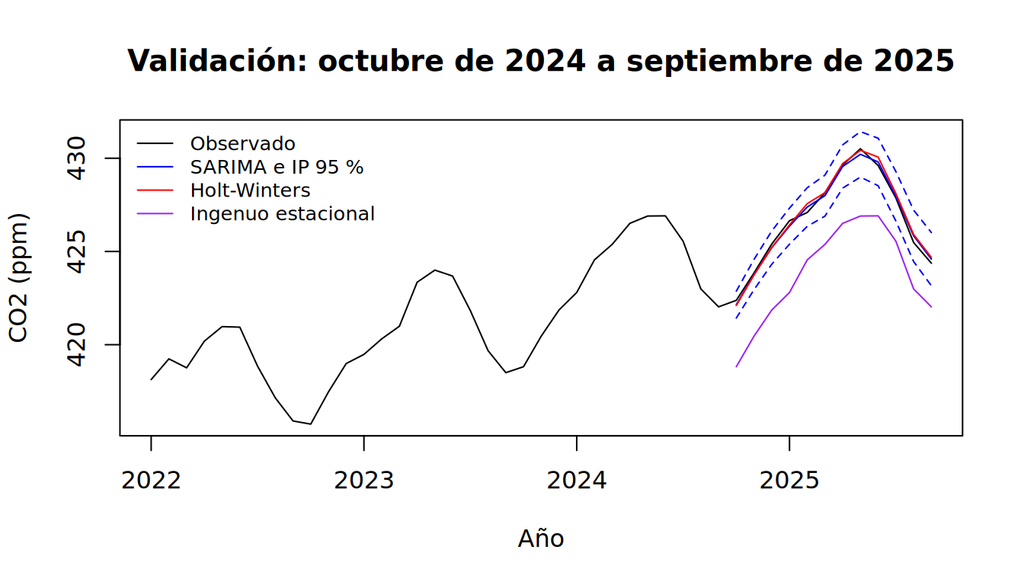

```r
ts.plot(window(z, start = c(2022, 1)), pA_val$pred, li, ls, hwA_val, ingenuo,
        col = c("black", "blue", "blue", "blue", "red", "purple"), lty = c(1, 1, 2, 2, 1, 1),
        ylab = "CO2 (ppm)", xlab = "Año", main = "Validación: octubre de 2024 a septiembre de 2025")
legend("topleft", c("Observado", "SARIMA e IP 95 %", "Holt-Winters", "Ingenuo estacional"),
       col = c("black", "blue", "red", "purple"), lty = 1, bty = "n", cex = 0.8)
```

**Respuesta.** El SARIMA obtiene los menores errores en los doce meses de validación: RMSE de 0,22538 ppm, MAPE de 0,048516 % y MASE de 0,081965. Su RMSE es 20,1 % menor que el de Holt-Winters. Las medidas se calculan con $e_j=Z_{n+j}-\widehat Z_n(j)$ y $h=12$:

$$RMSE=\sqrt{\frac1h\sum_{j=1}^he_j^2},\quad MAPE=\frac{100}{h}\sum_{j=1}^h\left|\frac{e_j}{Z_{n+j}}\right|,\quad MASE=\frac{h^{-1}\sum_{j=1}^h|e_j|}{(n-s)^{-1}\sum_{t=s+1}^n|Z_t-Z_{t-s}|}.$$

La escala del MASE es 2,525 ppm, de modo que el error absoluto del SARIMA representa el 8,2 % del error absoluto medio del ingenuo en entrenamiento. El ingenuo estacional obtiene un RMSE de 3,06623 ppm porque repite el año anterior sin incorporar el crecimiento del CO₂. Los 12 de los doce valores observados quedan dentro de los intervalos del 95 %, aunque la muestra es pequeña para comprobar su calibración.

### A6. Comprobación histórica complementaria

**Código en R**

```r
# Pronósticos a 12 meses desde cada septiembre, sin actualizar dentro del año.
# Los órdenes se mantienen fijos; cada ajuste usa solo su propio entrenamiento.
validarA <- function(n) {
  ent <- ts(z[1:n], start = c(2012, 1), frequency = 12)
  obs <- as.numeric(z[(n+1):(n+12)])
  sar <- arima(ent, order = orden_A$order,
               seasonal = list(order = orden_A$seasonal, period = 12),
               include.mean = FALSE, method = "ML")
  stopifnot(sar$code == 0)
  pr <- predict(sar, n.ahead = 12)
  hw <- predict(HoltWinters(ent, seasonal = "additive"), n.ahead = 12)
  pron <- list(SARIMA = pr$pred, HoltWinters = hw, Ingenuo = tail(ent, 12))
  escala <- mean(abs(diff(ent, 12)))
  res <- t(sapply(pron, function(x) medidas(obs, x, escala)))
  data.frame(origen = co2_datos$fecha[n], metodo = rownames(res), res,
             cobertura95 = c(sum(obs >= pr$pred-1.96*pr$se &
                                 obs <= pr$pred+1.96*pr$se), NA, NA),
             row.names = NULL)
}
histA <- do.call(rbind, lapply(seq(81, 141, by = 12), validarA))
knitr::kable(histA, digits = 4, caption = "Seis ventanas históricas de CO2")
```

Seis ventanas históricas de CO2

| origen | metodo | RMSE | MAE | MAPE | MASE | cobertura95 |
| --- | --- | --- | --- | --- | --- | --- |
| 2018-09 | SARIMA | 0.5569 | 0.4784 | 0.1163 | 0.1961 | 12 |
| 2018-09 | HoltWinters | 0.3544 | 0.3060 | 0.0744 | 0.1254 | NA |
| 2018-09 | Ingenuo | 2.9576 | 2.9367 | 0.7142 | 1.2035 | NA |
| 2019-09 | SARIMA | 0.2178 | 0.1920 | 0.0465 | 0.0764 | 12 |
| 2019-09 | HoltWinters | 0.2844 | 0.2373 | 0.0574 | 0.0944 | NA |
| 2019-09 | Ingenuo | 2.5586 | 2.5533 | 0.6174 | 1.0158 | NA |
| 2020-09 | SARIMA | 0.5434 | 0.4576 | 0.1101 | 0.1817 | 12 |
| 2020-09 | HoltWinters | 0.6895 | 0.6074 | 0.1460 | 0.2411 | NA |
| 2020-09 | Ingenuo | 2.3109 | 2.2775 | 0.5477 | 0.9042 | NA |
| 2021-09 | SARIMA | 0.4850 | 0.3789 | 0.0905 | 0.1521 | 12 |
| 2021-09 | HoltWinters | 0.5515 | 0.4266 | 0.1018 | 0.1712 | NA |
| 2021-09 | Ingenuo | 2.1822 | 2.1192 | 0.5073 | 0.8506 | NA |
| 2022-09 | SARIMA | 0.5019 | 0.3605 | 0.0859 | 0.1470 | 10 |
| 2022-09 | HoltWinters | 0.6081 | 0.4531 | 0.1078 | 0.1847 | NA |
| 2022-09 | Ingenuo | 2.4430 | 2.3617 | 0.5614 | 0.9627 | NA |
| 2023-09 | SARIMA | 0.7022 | 0.5731 | 0.1351 | 0.2344 | 12 |
| 2023-09 | HoltWinters | 0.5069 | 0.4108 | 0.0968 | 0.1680 | NA |
| 2023-09 | Ingenuo | 3.4281 | 3.3950 | 0.8011 | 1.3888 | NA |

**Código en R**

```r
rmseHistA <- sqrt(tapply(histA$RMSE^2, histA$metodo, mean))
knitr::kable(data.frame(metodo = names(rmseHistA), RMSE = as.numeric(rmseHistA)),
             digits = 5, caption = "RMSE conjunto de las seis ventanas")
```

RMSE conjunto de las seis ventanas

| metodo | RMSE |
| --- | --- |
| HoltWinters | 0.51846 |
| Ingenuo | 2.68070 |
| SARIMA | 0.52172 |

En los seis años anteriores, el RMSE conjunto del SARIMA es 0,5217 ppm y el de Holt-Winters es 0,5185 ppm. Los dos métodos tienen errores similares y superan al ingenuo estacional; en la validación oficial gana el SARIMA. Esta comprobación es retrospectiva, con órdenes fijos, y no sustituye la partición oficial.

## A7. El pronóstico del tablero

**Código en R**

```r
# Selección del tablero con A5 y A6, antes de reestimar.
metodo_tablero <- "SARIMA"
# Exigimos convergencia, invertibilidad y residuos sin rechazo de Ljung-Box.
# Se prefiere un modelo sin parámetros adicionales respaldados por sobreajuste.
reglasA <- data.frame(
  criterio = c("Convergencia ML", "Invertibilidad", "Ljung-Box al 5 %",
               "Parámetros significativos", "Sin mejora por sobreajuste (t)",
               "Menor RMSE oficial"),
  cumple = c(fitA$code == 0, raiz_regular > 1 && raiz_estacional > 1,
             lb$p.value >= .05, all(abs(tA) >= 1.96),
             all(abs(tab_sobre$t) < 1.96),
             compA[metodo_tablero, "RMSE"] == min(compA[, "RMSE"])))
knitr::kable(reglasA, caption = "Criterios de elección del SARIMA para el tablero")
```

Criterios de elección del SARIMA para el tablero

| criterio | cumple |
| --- | --- |
| Convergencia ML | TRUE |
| Invertibilidad | TRUE |
| Ljung-Box al 5 % | TRUE |
| Parámetros significativos | TRUE |
| Sin mejora por sobreajuste (t) | TRUE |
| Menor RMSE oficial | TRUE |

**Código en R**

```r
stopifnot(all(reglasA$cumple))
fitA_full <- arima(z, order=orden_A$order,
                   seasonal=list(order=orden_A$seasonal,period=12),
                   include.mean=FALSE, method="ML")
stopifnot(fitA_full$code == 0)
Theta_full <- -coef(fitA_full)["sma1"]
ic_Theta_full <- Theta_full + c(-1,1)*qnorm(.975)*sqrt(fitA_full$var.coef["sma1","sma1"])
print(fitA_full)
```

```
Call:
arima(x = z, order = orden_A$order, seasonal = list(order = orden_A$seasonal,
    period = 12), include.mean = FALSE, method = "ML")

Coefficients:
          ma1     sma1
      -0.4965  -0.9067
s.e.   0.0803   0.1181

sigma^2 estimated as 0.1228:  log likelihood = -66.36,  aic = 138.73
```

**Código en R**

```r
round(c(Theta_full=unname(Theta_full),ic_Theta_full),3)
```

```
Theta_full
     0.907      0.675      1.138
```

**Código en R**

```r
pf <- predict(fitA_full, n.ahead = 12)
tabA <- data.frame(fecha = format(seq(as.Date("2025-10-01"), by = "month", length.out = 12), "%Y-%m"),
                   pronostico = as.numeric(pf$pred),
                   li95 = as.numeric(pf$pred - 1.96 * pf$se),
                   ls95 = as.numeric(pf$pred + 1.96 * pf$se),
                   ancho = as.numeric(2 * 1.96 * pf$se))
knitr::kable(tabA, digits = 3, caption = "Pronóstico del CO2 (ppm), octubre de 2025 a septiembre de 2026")
```

Pronóstico del CO2 (ppm), octubre de 2025 a septiembre de 2026

| fecha | pronostico | li95 | ls95 | ancho |
| --- | --- | --- | --- | --- |
| 2025-10 | 424.631 | 423.939 | 425.323 | 1.384 |
| 2025-11 | 426.242 | 425.468 | 427.017 | 1.550 |
| 2025-12 | 427.702 | 426.853 | 428.552 | 1.699 |
| 2026-01 | 428.900 | 427.982 | 429.818 | 1.836 |
| 2026-02 | 429.770 | 428.788 | 430.751 | 1.963 |
| 2026-03 | 430.489 | 429.447 | 431.531 | 2.083 |
| 2026-04 | 432.051 | 430.952 | 433.149 | 2.196 |
| 2026-05 | 432.760 | 431.608 | 433.912 | 2.304 |
| 2026-06 | 432.175 | 430.972 | 433.379 | 2.407 |
| 2026-07 | 430.334 | 429.081 | 431.587 | 2.505 |
| 2026-08 | 428.217 | 426.917 | 429.517 | 2.600 |
| 2026-09 | 426.925 | 425.579 | 428.270 | 2.692 |

**Código en R**

```r
mayo <- tabA[tabA$fecha == "2026-05", ]
primero430 <- if(any(tabA$pronostico > 430)) tabA$fecha[which(tabA$pronostico > 430)[1]] else "ninguno en el horizonte"
cruce_obs <- co2_datos[which(co2_datos$co2_ppm > 430)[1], ]
apuesta <- cruce_obs$fecha  # primer cruce observado en los datos disponibles
# Archivo del tablero
tablero <- data.frame(pareja = pareja, fecha = tabA$fecha,
                      pronostico = sprintf("%.3f", tabA$pronostico))
dir.create("entregables", showWarnings = FALSE)
stopifnot(nrow(tablero)==12, all(is.finite(tabA$pronostico)))
write.csv(tablero, file.path("entregables", paste0("reto-co2_", pareja, ".csv")),
          row.names = FALSE, quote = FALSE)
tablero
```

```
           pareja   fecha pronostico
1  criollo-jurado 2025-10    424.631
2  criollo-jurado 2025-11    426.242
3  criollo-jurado 2025-12    427.702
4  criollo-jurado 2026-01    428.900
5  criollo-jurado 2026-02    429.770
6  criollo-jurado 2026-03    430.489
7  criollo-jurado 2026-04    432.051
8  criollo-jurado 2026-05    432.760
9  criollo-jurado 2026-06    432.175
10 criollo-jurado 2026-07    430.334
11 criollo-jurado 2026-08    428.217
12 criollo-jurado 2026-09    426.925
```

**Código en R**

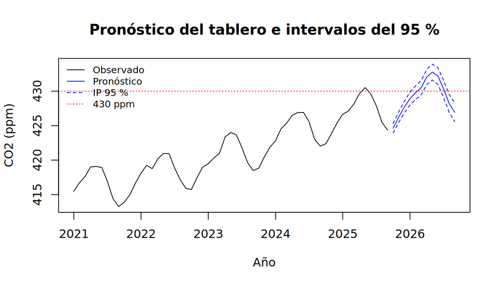

```r
ts.plot(window(z, start = c(2021, 1)), pf$pred, pf$pred - 1.96 * pf$se, pf$pred + 1.96 * pf$se,
        col = c("black", "blue", "blue", "blue"), lty = c(1, 1, 2, 2),
        ylab = "CO2 (ppm)", xlab = "Año", main = "Pronóstico del tablero e intervalos del 95 %")
abline(h = 430, col = "red", lty = 3)
legend("topleft", c("Observado", "Pronóstico", "IP 95 %", "430 ppm"),
       col = c("black", "blue", "blue", "red"), lty = c(1, 1, 2, 3),
       bty = "n", cex = 0.8)
```

**Respuesta.** Elegimos el SARIMA$(0,1,1)(0,1,1)_{12}$ para el tablero porque los residuos no muestran autocorrelación significativa y su RMSE de 0,22538 ppm es menor que el de las dos referencias. Al reestimar con los 165 meses, el pronóstico para mayo de 2026 es de 432,760 ppm con un intervalo del 95 % de [431,608; 433,912] ppm, y el primer mes pronosticado por encima de 430 ppm es 2026-03. El intervalo pasa de un ancho de 1,384 ppm en octubre a 2,692 ppm en septiembre porque las innovaciones futuras se acumulan en el error de pronóstico, cuya varianza, con $\psi_j$ como los pesos de la representación del modelo en innovaciones, es

$$V(h)=\sigma_a^2\sum_{j=0}^{h-1}\psi_j^2.$$

Si el crecimiento del CO₂ cambia de manera importante por las emisiones o la absorción de carbono, podría dejar de cumplirse el supuesto de innovaciones de media cero. Nuestra apuesta sobre el primer registro del observatorio es 2025-05, pues en ese mes se observan 430,51 ppm en el archivo; no tenemos datos anteriores a 2012 para confirmar si fue el primero de toda su historia.

# Caso B: viajeros del Reino Unido a Australia

La serie registra las llegadas trimestrales de visitantes, en miles, entre 1990-T1 y 2012-T3. Usamos 83 observaciones hasta 2010-T3 para estimar los modelos y reservamos los ocho trimestres restantes para evaluar los pronósticos.

## B1. Mirar y transformar

**Código en R**

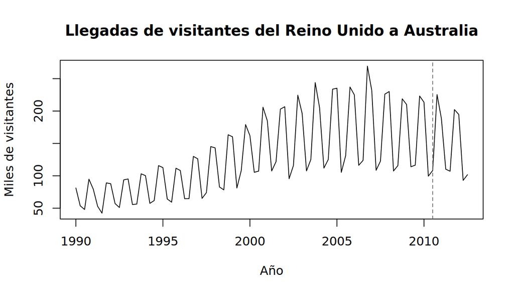

```r
b <- viajeros
btr <- viajeros_entrenamiento
bva <- viajeros_validacion
plot(b, main = "Llegadas de visitantes del Reino Unido a Australia",
     xlab = "Año", ylab = "Miles de visitantes")
abline(v = 2010.5, lty = 2, col = "grey40")
```

**Código en R**

```r
# Rango estacional de dos años completos.
amp90 <- diff(range(window(btr, start = c(1990,1), end = c(1990,4))))
amp05 <- diff(range(window(btr, start = c(2005,1), end = c(2005,4))))
c(amplitud_1990 = amp90, amplitud_2005 = amp05)
```

```
amplitud_1990 amplitud_2005
       46.790       131.683
```

**Código en R**

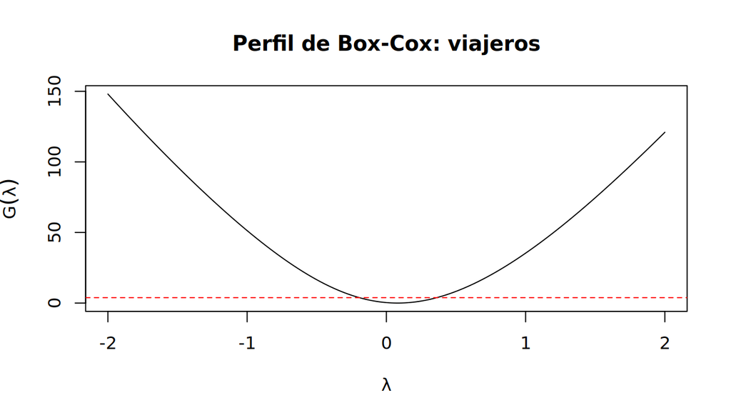

```r
# Perfil normalizado con el AR(4) sobre la doble diferencia.
pB <- perfil_bc(btr, 4, round(seq(-2, 2, by = 0.01), 2))
lamB <- pB$lambda[which.min(pB$G)]
GB <- function(l) pB$G[which.min(abs(pB$lambda - l))]
critB <- qchisq(0.95, 1)
plot(pB$lambda, pB$G, type = "l", xlab = expression(lambda),
     ylab = expression(G(lambda)), main = "Perfil de Box-Cox: viajeros")
abline(h = critB, col = "red", lty = 2)
```

**Código en R**

```r
c(lambda = lamB, G1 = GB(1), G05 = GB(0.5), G0 = GB(0),
  critico = critB)
```

```
    lambda         G1        G05         G0    critico
 0.0800000 35.3568682  8.2736319  0.3302817  3.8414588
```

**Código en R**

```r
lambda_B <- 0
```

**Respuesta.** En 1990 la diferencia entre el trimestre de mayor y menor número de visitantes fue de 46,790 mil, mientras que en 2005 fue de 131,683 mil. La oscilación crece con el nivel de la serie, por lo que conviene estudiar una transformación que estabilice la amplitud. Calculamos el perfil $G(\lambda)$ con la transformación normalizada y el AR(4) sobre $\nabla\nabla_4 Z_t^{(\lambda)}$, de la misma manera que en A2, pero con $n^*=83-4-5=74$.

**Prueba de Box-Cox para la ausencia de transformación**

1. $H_0:\lambda=1$; $H_1:\lambda\ne1$.
2. $G(1)=74\log[S(1)/S(\widehat\lambda)]\overset{\mathrm{aprox.}}{\sim}\chi^2_1$ bajo $H_0$.
3. Al 5 %, rechazamos $H_0$ si $G(1)>3,841$.
4. $G(1)=35,357$.
5. Rechazamos $H_0$.
6. La transformación identidad no resulta adecuada para la serie de viajeros.

Como $G(0,5)=8,274$ supera el valor crítico y $G(0)=0,330$ no lo supera, elegimos $\lambda=0$, es decir, trabajamos con $Y_t=\ln Z_t$.

## B2. ¿Cuántas diferencias?

**Código en R**

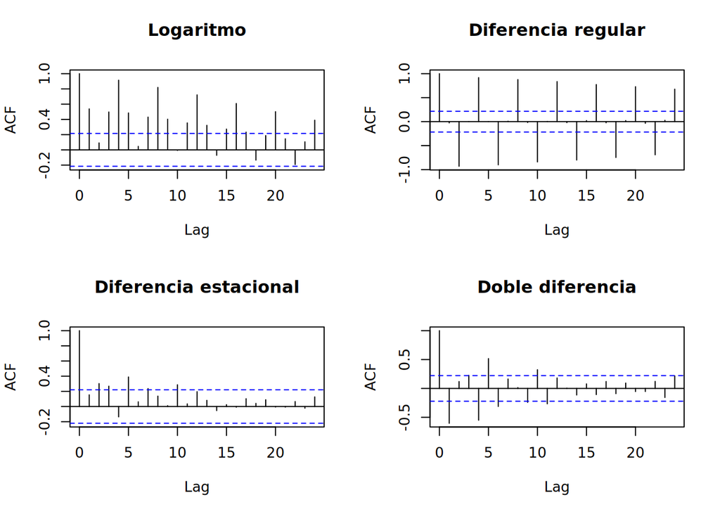

```r
Y <- log(btr)
Y4 <- diff(Y, lag = 4)
par(mfrow = c(2,2))
acf(as.numeric(Y), lag.max = 24, main = "Logaritmo")
acf(as.numeric(diff(Y)), lag.max = 24, main = "Diferencia regular")
acf(as.numeric(Y4), lag.max = 24, main = "Diferencia estacional")
acf(as.numeric(diff(Y4)), lag.max = 24, main = "Doble diferencia")
```

**Código en R**

```r
par(mfrow = c(1,1))
rY <- as.numeric(acf(Y, lag.max = 12, plot = FALSE)$acf)[-1]
round(rY[c(4,8,12)],3)
```

```
[1] 0.914 0.819 0.722
```

**Código en R**

```r
# ADF con constante: se comparan los rezagos sobre una muestra común.
# La serie diferenciada estacionalmente tiene media no necesariamente nula.
v <- as.numeric(Y4)
Pmax <- floor(12 * (length(v)/100)^(1/4))
dv <- diff(v)
X <- embed(dv, Pmax + 1)
base <- data.frame(dy = X[,1], y1 = v[(Pmax+1):(length(v)-1)])
for (j in seq_len(Pmax)) base[[paste0("d",j)]] <- X[,j+1]
bic_adf <- sapply(0:Pmax, function(P) {
  vars <- c("y1", if(P > 0) paste0("d",seq_len(P)))
  BIC(lm(reformulate(vars, response = "dy"), data = base))
})
PB <- which.min(bic_adf) - 1
knitr::kable(data.frame(P = 0:Pmax, BIC = bic_adf), digits = 3)
```

| P | BIC |
| --- | --- |
| 0 | -118.092 |
| 1 | -121.348 |
| 2 | -125.522 |
| 3 | -128.029 |
| 4 | -134.508 |
| 5 | -130.411 |
| 6 | -129.696 |
| 7 | -129.515 |
| 8 | -127.669 |
| 9 | -125.180 |
| 10 | -121.925 |
| 11 | -118.317 |

**Código en R**

```r
# Reestimación con el número de rezagos seleccionado.
adfB <- urca::ur.df(v, type = "drift", lags = PB, selectlags = "Fixed")
print(adfB@testreg)
```

```
Call:
lm(formula = z.diff ~ z.lag.1 + 1 + z.diff.lag)

Residuals:
      Min        1Q    Median        3Q       Max
-0.209705 -0.048019 -0.004198  0.052787  0.193441

Coefficients:
            Estimate Std. Error t value Pr(>|t|)
(Intercept)  0.01358    0.01186   1.145 0.256117
z.lag.1     -0.33269    0.16986  -1.959 0.054258 .
z.diff.lag1 -0.43716    0.15855  -2.757 0.007479 **
z.diff.lag2 -0.13535    0.15715  -0.861 0.392113
z.diff.lag3 -0.02777    0.14571  -0.191 0.849406
z.diff.lag4 -0.38171    0.11088  -3.442 0.000991 ***
---
Signif. codes:  0 '***' 0.001 '**' 0.01 '*' 0.05 '.' 0.1 ' ' 1

Residual standard error: 0.07491 on 68 degrees of freedom
Multiple R-squared:  0.6333,    Adjusted R-squared:  0.6063
F-statistic: 23.48 on 5 and 68 DF,  p-value: 1.254e-13
```

**Código en R**

```r
tauB <- as.numeric(adfB@teststat[1,"tau2"])
Nadf <- length(v) - 1 - PB
cvB <- urca::qunitroot(0.05, N = Nadf, trend = "c")
c(Pmax = Pmax, P = PB, N = Nadf, tau = tauB, critico = cvB)
```

```
     Pmax         P         N       tau   critico
11.000000  4.000000 74.000000 -1.958635 -2.901200
```

**Código en R**

```r
# Decisión con los resultados de la prueba.
dB <- as.integer(tauB >= cvB)
DB <- 1
stopifnot(dB == 1)
WB <- diff(Y4)
```

**Respuesta.** En el logaritmo, las autocorrelaciones de los rezagos 4, 8 y 12 son 0,914; 0,819; 0,722. Su descenso lento muestra persistencia entre los mismos trimestres de distintos años, por lo que tomamos $D=1$. Sobre $V_t=\nabla_4Y_t$ usamos una prueba ADF con constante, pues el crecimiento interanual puede tener una media distinta de cero; no incluimos una tendencia determinista en esta regresión.

**Prueba aumentada de Dickey y Fuller**

1. $H_0:\gamma=0$ (raíz unitaria en $V_t$); $H_1:\gamma<0$ (estacionariedad alrededor de una constante).
2. En $\Delta V_t=c+\gamma V_{t-1}+\sum_{j=1}^{P}\delta_j\Delta V_{t-j}+a_t$, usamos $\tau=\widehat\gamma/ee(\widehat\gamma)$, con distribución Dickey-Fuller para el caso con constante, no una t de Student. El máximo de rezagos es $P_{\max}=\lfloor12(n/100)^{1/4}\rfloor=$ 11, y BIC sobre una muestra común elige $P=$ 4; la reestimación usa 74 observaciones (referencia de Dickey-Fuller, sin grados de libertad t).
3. Al 5 %, rechazamos si $\tau<-2,901$.
4. $\tau=-1,959$.
5. No rechazamos $H_0$ al 5 %.
6. No encontramos evidencia suficiente de estacionariedad tras aplicar solo la diferencia estacional; por eso tomamos $d=1$.

Trabajamos con $W_t=(1-B)(1-B^4)\ln Z_t$, que tiene 78 observaciones, sin constante en el SARIMA porque $d+D=2$.

## B3. Dos candidatos

**Código en R**

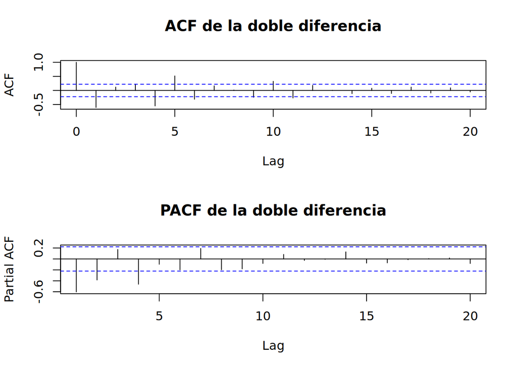

```r
par(mfrow = c(2,1))
acf(as.numeric(WB), lag.max = 20, main = "ACF de la doble diferencia")
pacf(as.numeric(WB), lag.max = 20, main = "PACF de la doble diferencia")
```

**Código en R**

```r
par(mfrow = c(1,1))
rB <- as.numeric(acf(WB, lag.max = 20, plot = FALSE)$acf)[-1]
pBcor <- as.numeric(pacf(WB, lag.max = 20, plot = FALSE)$acf)
rezB <- c(1:6,8,12,16)
knitr::kable(data.frame(rezago = rezB, ACF = rB[rezB],
                        PACF = pBcor[rezB]), digits = 3)
```

| rezago | ACF | PACF |
| --- | --- | --- |
| 1 | -0.603 | -0.603 |
| 2 | 0.119 | -0.384 |
| 3 | 0.226 | 0.173 |
| 4 | -0.550 | -0.462 |
| 5 | 0.516 | -0.097 |
| 6 | -0.311 | -0.200 |
| 8 | 0.014 | -0.198 |
| 12 | 0.181 | -0.027 |
| 16 | -0.106 | -0.071 |

**Código en R**

```r
# p, q, P, Q; comparamos en una muestra común de residuos.
canB <- rbind(c(0,1,0,1), c(1,0,0,1), c(0,1,1,0), c(1,0,1,0),
              c(1,1,0,1), c(0,2,0,1), c(0,1,0,2), c(0,1,1,1))
tabB <- criterios_css(WB, canB, 4)
knitr::kable(tabB, digits = 3, caption = "AIC y SBC (BIC) condicionales")
```

AIC y SBC (BIC) condicionales

| p | q | P | Q | N | M | AIC | SBC | codigo | dSBC |
| --- | --- | --- | --- | --- | --- | --- | --- | --- | --- |
| 0 | 1 | 0 | 1 | 73 | 2 | -377.432 | -372.851 | 0 | 0.000 |
| 0 | 1 | 1 | 1 | 73 | 3 | -379.275 | -372.403 | 0 | 0.448 |
| 0 | 2 | 0 | 1 | 73 | 3 | -377.892 | -371.021 | 0 | 1.830 |
| 0 | 1 | 0 | 2 | 73 | 3 | -377.827 | -370.956 | 0 | 1.895 |
| 1 | 1 | 0 | 1 | 73 | 3 | -377.742 | -370.871 | 0 | 1.980 |
| 0 | 1 | 1 | 0 | 73 | 2 | -375.349 | -370.768 | 0 | 2.083 |
| 1 | 0 | 0 | 1 | 73 | 2 | -366.913 | -362.332 | 0 | 10.519 |
| 1 | 0 | 1 | 0 | 73 | 2 | -364.514 | -359.933 | 0 | 12.918 |

**Código en R**

```r
# Los dos primeros modelos de la comparación.
stopifnot(all(tabB$codigo[1:2] == 0))
oB1 <- as.integer(unlist(tabB[1,c("p","q","P","Q")]))
oB2 <- as.integer(unlist(tabB[2,c("p","q","P","Q")]))
nombreB <- function(o) sprintf("(%d,1,%d)(%d,1,%d)_4",o[1],o[2],o[3],o[4])
c(candidato1 = nombreB(oB1), candidato2 = nombreB(oB2))
```

```
        candidato1         candidato2
"(0,1,1)(0,1,1)_4" "(0,1,1)(1,1,1)_4"
```

**Respuesta.** La ACF en los rezagos 1 y 2 es -0,603 y 0,119, y la PACF es -0,603 y -0,384; esto sugiere un MA(1) regular. En la parte estacional, la ACF en 4, 8 y 12 es -0,550; 0,014; 0,181 y la PACF es -0,462; -0,198; -0,027, por lo que probamos un MA(1) estacional y un modelo con AR estacional adicional. Los rezagos 3 y 5 son satélites del MA multiplicativo; la ACF también sobresale en 6, lo que indica que la huella no es exacta. El menor SBC es -372,851 para el SARIMA(0,1,1)(0,1,1)_4 y el segundo es -372,403 para el SARIMA(0,1,1)(1,1,1)_4. Como solo los separan 0,448 unidades, conservamos ambos para la validación.

## B4. Estimar, validar y buscar atípicos

**Código en R**

```r
ajustarB <- function(x,o) {
  arima(x, order = c(o[1],1,o[2]),
        seasonal = list(order = c(o[3],1,o[4]), period = 4),
        include.mean = FALSE, method = "ML")
}
fitB1 <- ajustarB(Y,oB1)
fitB2 <- ajustarB(Y,oB2)
stopifnot(fitB1$code == 0, fitB2$code == 0)
coefB <- function(fit) {
  co <- coef(fit)
  co[grepl("^(ma|sma)",names(co))] <- -co[grepl("^(ma|sma)",names(co))]
  ee <- sqrt(diag(fit$var.coef))
  data.frame(parametro = names(co), estimacion = as.numeric(co),
             ee = as.numeric(ee), t = as.numeric(co/ee))
}
tB1 <- coefB(fitB1); tB2 <- coefB(fitB2)
knitr::kable(tB1, digits = 3, caption = "Candidato 1: coeficientes y errores estándar")
```

Candidato 1: coeficientes y errores estándar

| parametro | estimacion | ee | t |
| --- | --- | --- | --- |
| ma1 | 0.676 | 0.077 | 8.768 |
| sma1 | 0.599 | 0.087 | 6.872 |

**Código en R**

```r
knitr::kable(tB2, digits = 3, caption = "Candidato 2: coeficientes y errores estándar")
```

Candidato 2: coeficientes y errores estándar

| parametro | estimacion | ee | t |
| --- | --- | --- | --- |
| ma1 | 0.663 | 0.078 | 8.464 |
| sar1 | -0.238 | 0.162 | -1.476 |
| sma1 | 0.465 | 0.139 | 3.339 |

**Código en R**

```r
c(varianza1 = fitB1$sigma2, varianza2 = fitB2$sigma2)
```

```
  varianza1   varianza2
0.005302263 0.005156808
```

**Código en R**

```r
# Polinomios con los coeficientes estimados; signos en la notación del curso.
polinomio <- function(co, prefijo, s = 1) {
  v <- co[grepl(paste0("^",prefijo,"[0-9]+$"),names(co))]
  if (!length(v)) return("")
  tr <- paste0(ifelse(v >= 0,"-","+"), formatC(abs(v),digits=3,format="f"),
               "B", ifelse(seq_along(v)*s == 1,"",paste0("^{",seq_along(v)*s,"}")))
  paste0("(1",paste(tr,collapse=""),")")
}
ecuacionB <- function(fit) {
  cf <- coef(fit)
  izq <- paste0(polinomio(cf,"ar"),polinomio(cf,"sar",4),
                "\\nabla\\nabla_4 \\ln Z_t")
  # En R los MA tienen signo opuesto; la función recibe la convención del curso.
  cf[grepl("^(ma|sma)",names(cf))] <- -cf[grepl("^(ma|sma)",names(cf))]
  der <- paste0(polinomio(cf,"ma"),polinomio(cf,"sma",4),"a_t")
  paste0("$$",izq,"=",der,",\\qquad \\widehat{\\sigma}_a^2=",
         formatC(fit$sigma2,format="f",digits=6),".$$\n\n")
}
cat("**Candidato 1**\n\n",ecuacionB(fitB1),
    "**Candidato 2**\n\n",ecuacionB(fitB2))
```

**Candidato 1**

$$\nabla\nabla_4 \ln Z_t=(1-0.676B)(1-0.599B^{4})a_t,\qquad \widehat{\sigma}_a^2=0.005302.$$

**Candidato 2**

$$(1+0.238B^{4})\nabla\nabla_4 \ln Z_t=(1-0.663B)(1-0.465B^{4})a_t,\qquad \widehat{\sigma}_a^2=0.005157.$$

**Código en R**

```r
# Se eliminan d+sD = 5 residuos iniciales.
eB1 <- as.numeric(residuals(fitB1))[-(1:5)]
eB2 <- as.numeric(residuals(fitB2))[-(1:5)]
K <- c(8,12,16)
lbB <- function(e,fit,nombre) {
  m <- length(coef(fit))
  do.call(rbind,lapply(K,function(k) {
    pr <- Box.test(e,lag=k,type="Ljung-Box",fitdf=m)
    data.frame(modelo=nombre,K=k,gl=k-m,Q=unname(pr$statistic),
               critico=qchisq(.95,k-m),p=pr$p.value)
  }))
}
LB <- rbind(lbB(eB1,fitB1,"Candidato 1"),lbB(eB2,fitB2,"Candidato 2"))
knitr::kable(LB,digits=4,caption="Ljung-Box para los dos candidatos")
```

Ljung-Box para los dos candidatos

| modelo | K | gl | Q | critico | p |
| --- | --- | --- | --- | --- | --- |
| Candidato 1 | 8 | 6 | 9.5339 | 12.5916 | 0.1457 |
| Candidato 1 | 12 | 10 | 18.8825 | 18.3070 | 0.0418 |
| Candidato 1 | 16 | 14 | 20.0833 | 23.6848 | 0.1275 |
| Candidato 2 | 8 | 5 | 7.0745 | 11.0705 | 0.2152 |
| Candidato 2 | 12 | 9 | 15.0466 | 16.9190 | 0.0897 |
| Candidato 2 | 16 | 13 | 16.5573 | 22.3620 | 0.2203 |

**Código en R**

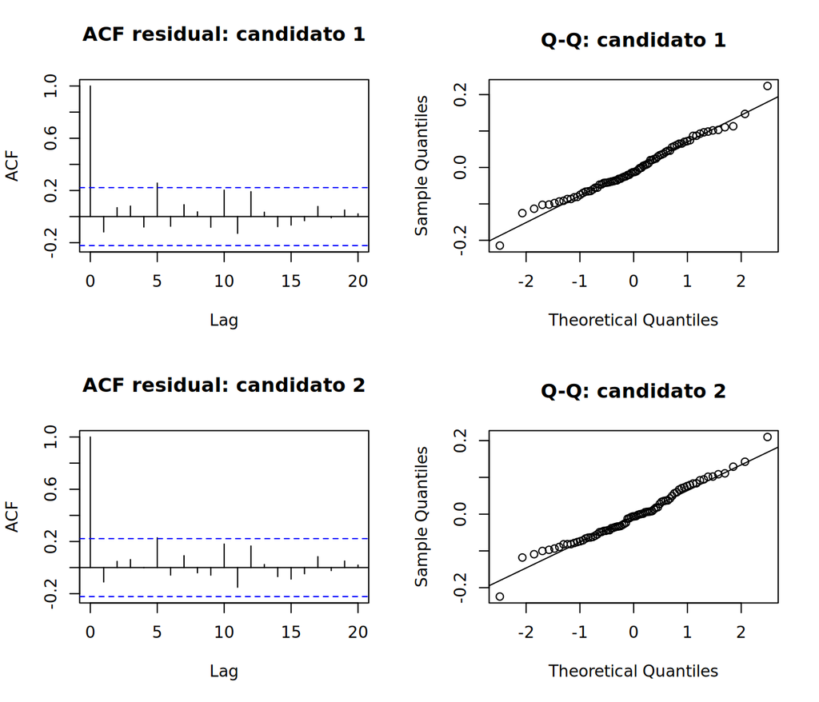

```r
par(mfrow=c(2,2))
acf(eB1,lag.max=20,main="ACF residual: candidato 1")
qqnorm(eB1,main="Q-Q: candidato 1"); qqline(eB1)
acf(eB2,lag.max=20,main="ACF residual: candidato 2")
qqnorm(eB2,main="Q-Q: candidato 2"); qqline(eB2)
```

**Código en R**

```r
par(mfrow=c(1,1))
# Normalidad como diagnóstico adicional.
normalB <- function(e) {
  u <- e-mean(e); S <- mean(u^3)/mean(u^2)^(3/2)
  C <- mean(u^4)/mean(u^2)^2
  JB <- length(e)*(S^2/6+(C-3)^2/24)
  c(asimetria=S,curtosis=C,JB=JB,p=pchisq(JB,2,lower.tail=FALSE))
}
knitr::kable(rbind(normalB(eB1),normalB(eB2)),digits=3,
             caption="Diagnóstico de normalidad")
```

Diagnóstico de normalidad

| asimetria | curtosis | JB | p |
| --- | --- | --- | --- |
| 0.231 | 3.419 | 1.265 | 0.531 |
| 0.193 | 3.483 | 1.245 | 0.537 |

**Código en R**

```r
# Mismo filtro de intervenciones de A5; contraste metodológico pendiente.
atB1 <- atipicos(fitB1)
atB2 <- atipicos(fitB2)
maxB <- rbind(apply(abs(atB1[,-1]),2,max),apply(abs(atB2[,-1]),2,max))
rownames(maxB) <- c("Candidato 1","Candidato 2")
knitr::kable(maxB,digits=3,caption="Máximo absoluto por tipo de atípico")
```

Máximo absoluto por tipo de atípico

|  | IO | AO | LS | TC |
| --- | --- | --- | --- | --- |
| Candidato 1 | 2.939 | 2.487 | 2.191 | 1.993 |
| Candidato 2 | 3.106 | 2.376 | 2.161 | 2.425 |

**Código en R**

```r
alertB <- function(a) a[apply(abs(a[,-1]),1,max)>3.5,]
alertB(atB1); alertB(atB2)
```

```
[1] T  IO AO LS TC
<0 rows> (or 0-length row.names)
```

```
[1] T  IO AO LS TC
<0 rows> (or 0-length row.names)
```

**Código en R**

```r
sobra1 <- tB1[abs(tB1$t)<1.96,]
sobra2 <- tB2[abs(tB2$t)<1.96,]
sobra1; sobra2
```

```
[1] parametro  estimacion ee         t
<0 rows> (or 0-length row.names)
```

```
  parametro estimacion        ee        t
2      sar1 -0.2384701 0.1615202 -1.47641
```

**Respuesta.** Las ecuaciones anteriores están escritas en la convención del curso, es decir, los parámetros MA corresponden al negativo de los reportados por R, con $a_t\sim WN(0,\sigma_a^2)$ en cada modelo.

**Pruebas de Ljung y Box** (para cada modelo y cada $K=8,12,16$):

1. $H_0:\rho_1=\cdots=\rho_K=0$; $H_1:$ al menos una autocorrelación residual no es cero.
2. $Q_{LB}=N'(N'+2)\sum_{j=1}^K\widehat r_j^2/(N'-j)\overset{\mathrm{aprox.}}{\sim}\chi^2_{K-m}$ bajo $H_0$, con $N'=$ 78 y $m=$ 2 o 3 según el candidato.
3. Rechazamos al 5 % cuando $Q_{LB}>\chi^2_{K-m;0,95}$; la tabla anterior muestra los seis valores críticos y sus grados de libertad.
4. Los estadísticos del candidato 1 son 9,534; 18,883; 20,083 y los del candidato 2 son 7,074; 15,047; 16,557, respectivamente.
5. Rechazamos en Candidato 1 (K=12) y no rechazamos en las restantes.
6. El candidato 1 presenta evidencia de autocorrelación residual para K = 12 (p = 0,0418); el candidato 2 no es rechazado para ninguno de los tres rezagos.

Con los filtros de AO, IO, LS y TC, $\delta=0,7$ y $\widehat\sigma_a=1,483\,MAD$, obtuvimos máximos de 2,939 y 3,106 para los dos modelos. No se detectan atípicos con el umbral 3,5. La búsqueda se realizó mediante filtros de intervención y falta comprobarla con el material específico de atípicos. Los parámetros con menor respaldo son candidato 2: sar1 (t=-1,476) porque sus estadísticos no superan 1,96 en valor absoluto.

## B5. Evaluación en ocho trimestres

**Código en R**

```r
pB1 <- predict(fitB1,n.ahead=8)
pB2 <- predict(fitB2,n.ahead=8)
med1 <- exp(pB1$pred)
med2 <- exp(pB2$pred)
media1 <- exp(pB1$pred+pB1$se^2/2)
media2 <- exp(pB2$pred+pB2$se^2/2)
ingB <- ts(rep(tail(btr,4),2),start=c(2010,4),frequency=4)
hwB <- HoltWinters(btr,seasonal="multiplicative")
phwB <- predict(hwB,n.ahead=8)
escalaB <- mean(abs(diff(btr,4)))
compB <- rbind("SARIMA 1 - mediana"=medidas(bva,med1,escalaB),
               "SARIMA 2 - mediana"=medidas(bva,med2,escalaB),
               "SARIMA 1 - media"=medidas(bva,media1,escalaB),
               "Ingenuo estacional"=medidas(bva,ingB,escalaB),
               "Holt-Winters multiplicativo"=medidas(bva,phwB,escalaB))
knitr::kable(compB,digits=4,caption="Errores de validación: RMSE y MAE en miles, MAPE en %, MASE sin unidades")
```

Errores de validación: RMSE y MAE en miles, MAPE en %, MASE sin unidades

|  | RMSE | MAE | MAPE | MASE |
| --- | --- | --- | --- | --- |
| SARIMA 1 - mediana | 8.3381 | 6.7405 | 4.3593 | 0.6837 |
| SARIMA 2 - mediana | 8.1542 | 6.2214 | 3.9237 | 0.6310 |
| SARIMA 1 - media | 8.5410 | 7.1715 | 4.6694 | 0.7274 |
| Ingenuo estacional | 14.2659 | 11.4963 | 7.3152 | 1.1661 |
| Holt-Winters multiplicativo | 7.6094 | 5.3685 | 3.3876 | 0.5445 |

**Código en R**

```r
c(escala_MASE=escalaB, factor_min=min(exp(pB1$se^2/2)),
  factor_max=max(exp(pB1$se^2/2)))
```

```
escala_MASE  factor_min  factor_max
   9.858823    1.002655    1.006548
```

**Código en R**

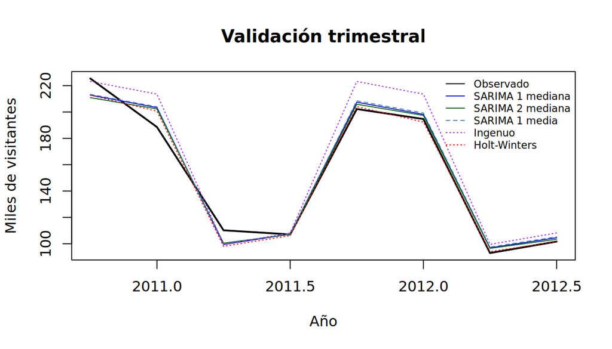

```r
ordenB <- order(compB[,"RMSE"])

# Visualizamos las ocho observaciones reservadas y los cinco pronósticos.
ts.plot(bva,med1,med2,media1,ingB,phwB,
        col=c("black","blue","darkgreen","steelblue","purple","red"),
        lty=c(1,1,1,2,3,3),lwd=c(2,1,1,1,1,1),
        ylab="Miles de visitantes", xlab="Año", main="Validación trimestral")
legend("topright",c("Observado","SARIMA 1 mediana","SARIMA 2 mediana",
       "SARIMA 1 media","Ingenuo","Holt-Winters"),
       col=c("black","blue","darkgreen","steelblue","purple","red"),
       lty=c(1,1,1,2,3,3),cex=.7,bty="n")
```

**Respuesta.** Comparamos los cinco pronósticos con las mismas medidas de A6; la escala estacional del MASE es 9,859 mil visitantes. Si el pronóstico en logaritmos es $\widehat Y_n(\ell)$ y la varianza del error es $v_\ell$, entonces

$$\operatorname{Med}(Z_{n+\ell}\mid\mathcal F_n)=e^{\widehat Y_n(\ell)},\qquad E(Z_{n+\ell}\mid\mathcal F_n)=e^{\widehat Y_n(\ell)}e^{v_\ell/2}.$$

### B5. Comprobación histórica complementaria

**Código en R**

```r
# Cada origen termina en T3 y reserva los ocho trimestres siguientes.
# Se reestiman los mismos órdenes sin usar datos posteriores al origen.
validarB <- function(anio) {
  tr <- window(b, end = c(anio, 3))
  va <- window(b, start = c(anio, 4), end = c(anio+2, 3))
  stopifnot(length(va) == 8)
  m1 <- ajustarB(log(tr), oB1)
  m2 <- ajustarB(log(tr), oB2)
  stopifnot(m1$code == 0, m2$code == 0)
  p1 <- predict(m1, n.ahead = 8)
  p2 <- predict(m2, n.ahead = 8)
  hw <- predict(HoltWinters(tr, seasonal = "multiplicative"), n.ahead = 8)
  pron <- list(SAR1_mediana = exp(p1$pred),
               SAR1_media = exp(p1$pred + p1$se^2/2),
               SAR2_mediana = exp(p2$pred),
               SAR2_media = exp(p2$pred + p2$se^2/2),
               HW = hw, Ingenuo = rep(tail(tr, 4), 2))
  escala <- mean(abs(diff(tr, 4)))
  res <- t(sapply(pron, function(x) medidas(va, x, escala)))
  data.frame(origen = paste0(anio, "-T3"), metodo = rownames(res),
             res, row.names = NULL)
}
histB <- do.call(rbind, lapply(c(2004, 2006, 2008), validarB))
knitr::kable(histB, digits = 4, caption = "Tres ventanas históricas de viajeros")
```

Tres ventanas históricas de viajeros

| origen | metodo | RMSE | MAE | MAPE | MASE |
| --- | --- | --- | --- | --- | --- |
| 2004-T3 | SAR1_mediana | 12.6662 | 11.2302 | 6.9260 | 1.1679 |
| 2004-T3 | SAR1_media | 13.2133 | 11.8912 | 7.3458 | 1.2366 |
| 2004-T3 | SAR2_mediana | 12.0622 | 10.2488 | 6.2470 | 1.0658 |
| 2004-T3 | SAR2_media | 12.5339 | 10.8909 | 6.6556 | 1.1326 |
| 2004-T3 | HW | 11.0430 | 9.1080 | 5.3283 | 0.9472 |
| 2004-T3 | Ingenuo | 13.7772 | 10.5596 | 5.5163 | 1.0982 |
| 2006-T3 | SAR1_mediana | 15.4968 | 13.1452 | 8.2100 | 1.3506 |
| 2006-T3 | SAR1_media | 15.9106 | 13.5973 | 8.5515 | 1.3971 |
| 2006-T3 | SAR2_mediana | 14.6749 | 12.1946 | 7.5145 | 1.2529 |
| 2006-T3 | SAR2_media | 15.0442 | 12.6183 | 7.8375 | 1.2965 |
| 2006-T3 | HW | 13.9726 | 11.4951 | 6.9846 | 1.1811 |
| 2006-T3 | Ingenuo | 13.3935 | 10.0954 | 5.6349 | 1.0373 |
| 2008-T3 | SAR1_mediana | 8.4650 | 7.7465 | 4.9665 | 0.7705 |
| 2008-T3 | SAR1_media | 9.0938 | 8.4088 | 5.3660 | 0.8364 |
| 2008-T3 | SAR2_mediana | 9.1588 | 7.8167 | 4.8011 | 0.7775 |
| 2008-T3 | SAR2_media | 9.6938 | 8.4305 | 5.1690 | 0.8385 |
| 2008-T3 | HW | 7.1183 | 5.7505 | 3.6965 | 0.5720 |
| 2008-T3 | Ingenuo | 10.5856 | 8.6682 | 5.3949 | 0.8622 |

**Código en R**

```r
rmseHistB <- sqrt(tapply(histB$RMSE^2, histB$metodo, mean))
knitr::kable(data.frame(metodo = names(rmseHistB), RMSE = as.numeric(rmseHistB)),
             digits = 5, caption = "RMSE conjunto de las tres ventanas")
```

RMSE conjunto de las tres ventanas

| metodo | RMSE |
| --- | --- |
| HW | 11.07325 |
| Ingenuo | 12.66558 |
| SAR1_media | 13.04401 |
| SAR1_mediana | 12.54647 |
| SAR2_media | 12.61472 |
| SAR2_mediana | 12.17560 |

Holt-Winters obtiene el menor RMSE conjunto (11,0732 mil visitantes), seguido por la mediana del segundo SARIMA (12,1756 mil). Entre los SARIMA, la mediana del segundo candidato vuelve a tener el menor error conjunto. Recomendamos Holt-Winters si la prioridad es la precisión operativa; para el análisis SARIMA elegimos el modelo con mejores residuos y menor RMSE entre los candidatos. Estas ventanas usan órdenes fijos y son un complemento retrospectivo, no una nueva selección independiente.

## B6. El pronóstico para la aerolínea

**Código en R**

```r
# Primero exigimos que Ljung-Box no rechace al 5 % en K = 8, 12, 16.
# Luego preferimos parámetros significativos; si ninguno cumple ambos
# criterios, conservamos el que tenga residuos adecuados y lo justificamos.
valido <- c(all(LB$p[1:3]>=.05),all(LB$p[4:6]>=.05))
parsimonioso <- c(nrow(sobra1)==0,nrow(sobra2)==0)
# Comprobación adicional: media y mediana del segundo candidato.
compRetrans2 <- rbind(Mediana = medidas(bva, med2, escalaB),
                      Media = medidas(bva, media2, escalaB))
knitr::kable(compRetrans2, digits = 4,
             caption = "Retransformación del segundo SARIMA")
```

Retransformación del segundo SARIMA

|  | RMSE | MAE | MAPE | MASE |
| --- | --- | --- | --- | --- |
| Mediana | 8.1542 | 6.2214 | 3.9237 | 0.631 |
| Media | 8.2718 | 6.6149 | 4.2069 | 0.671 |

**Código en R**

```r
rmseSar <- c(min(compB[c(1,3),"RMSE"]), min(compRetrans2[,"RMSE"]))
# Comparación explícita de las restricciones en el entrenamiento.
reglasB <- data.frame(candidato = c(nombreB(oB1), nombreB(oB2)),
                      SBC = tabB$SBC[1:2],
                      convergencia = c(fitB1$code, fitB2$code) == 0,
                      Ljung_Box = valido, todos_t_significativos = parsimonioso,
                      RMSE = rmseSar)
knitr::kable(reglasB, digits = 4, caption = "Restricciones de selección del caso B")
```

Restricciones de selección del caso B

| candidato | SBC | convergencia | Ljung_Box | todos_t_significativos | RMSE |
| --- | --- | --- | --- | --- | --- |
| (0,1,1)(0,1,1)_4 | -372.8509 | TRUE | FALSE | TRUE | 8.3381 |
| (0,1,1)(1,1,1)_4 | -372.4033 | TRUE | TRUE | FALSE | 8.1542 |

**Código en R**

```r
elegibles <- which(valido & parsimonioso)
if (!length(elegibles)) elegibles <- which(valido)
# No se selecciona automáticamente un modelo si ambos fallan el diagnóstico.
if (!length(elegibles)) stop("Revisar ambos SARIMA: fallan el diagnóstico residual")
finalB <- elegibles[which.min(rmseSar[elegibles])]
ordenFinalB <- if(finalB==1) oB1 else oB2
# Para planear capacidad usamos la mediana si su RMSE de validación es menor.
rmseMed <- if (finalB == 1) compB[1,"RMSE"] else compRetrans2[1,"RMSE"]
rmseMedia <- if (finalB == 1) compB[3,"RMSE"] else compRetrans2[2,"RMSE"]
retransB <- if (rmseMedia < rmseMed) "media" else "mediana"
fitBfull <- ajustarB(log(b),ordenFinalB)
stopifnot(fitBfull$code==0)
# Diagnóstico final de ambos modelos, después de elegir con el entrenamiento.
fitB1full <- ajustarB(log(b), oB1)
fitB2full <- ajustarB(log(b), oB2)
stopifnot(fitB1full$code == 0, fitB2full$code == 0)
LBcompleto <- rbind(lbB(residuals(fitB1full)[-(1:5)], fitB1full, "Candidato 1"),
                    lbB(residuals(fitB2full)[-(1:5)], fitB2full, "Candidato 2"))
knitr::kable(LBcompleto, digits = 4, caption = "Ljung-Box de ambos SARIMA con 91 datos")
```

Ljung-Box de ambos SARIMA con 91 datos

| modelo | K | gl | Q | critico | p |
| --- | --- | --- | --- | --- | --- |
| Candidato 1 | 8 | 6 | 12.1698 | 12.5916 | 0.0583 |
| Candidato 1 | 12 | 10 | 18.8194 | 18.3070 | 0.0426 |
| Candidato 1 | 16 | 14 | 20.3841 | 23.6848 | 0.1185 |
| Candidato 2 | 8 | 5 | 7.5786 | 11.0705 | 0.1810 |
| Candidato 2 | 12 | 9 | 12.9376 | 16.9190 | 0.1654 |
| Candidato 2 | 16 | 13 | 14.5411 | 22.3620 | 0.3369 |

**Código en R**

```r
tcompleto <- rbind(data.frame(candidato = 1, coefB(fitB1full)),
                   data.frame(candidato = 2, coefB(fitB2full)))
knitr::kable(tcompleto, digits = 4, caption = "Significancia de ambos modelos reestimados")
```

Significancia de ambos modelos reestimados

| candidato | parametro | estimacion | ee | t |
| --- | --- | --- | --- | --- |
| 1 | ma1 | 0.6859 | 0.0710 | 9.6641 |
| 1 | sma1 | 0.6141 | 0.0819 | 7.4965 |
| 2 | ma1 | 0.6729 | 0.0725 | 9.2772 |
| 2 | sar1 | -0.2960 | 0.1508 | -1.9638 |
| 2 | sma1 | 0.4475 | 0.1348 | 3.3200 |

**Código en R**

```r
eBfull <- residuals(fitBfull)[-(1:5)]
lbBfull <- lbB(eBfull, fitBfull, "Modelo final")
knitr::kable(coefB(fitBfull),digits=3,caption="Modelo de viajeros reestimado con 91 observaciones")
```

Modelo de viajeros reestimado con 91 observaciones

| parametro | estimacion | ee | t |
| --- | --- | --- | --- |
| ma1 | 0.673 | 0.073 | 9.277 |
| sar1 | -0.296 | 0.151 | -1.964 |
| sma1 | 0.447 | 0.135 | 3.320 |

**Código en R**

```r
pfB <- predict(fitBfull,n.ahead=8)
muB <- as.numeric(pfB$pred); seB <- as.numeric(pfB$se)
medB <- exp(muB); espB <- exp(muB+seB^2/2)
liB <- exp(muB-1.96*seB); lsB <- exp(muB+1.96*seB)
fechaB <- c("2012-T4",paste0("2013-T",1:4),paste0("2014-T",1:3))
tablaFinalB <- data.frame(trimestre=fechaB,mediana=medB,media=espB,
                          LI95=liB,LS95=lsB)
knitr::kable(tablaFinalB,digits=3,caption="Pronósticos e intervalos del 95 % (miles de visitantes)")
```

Pronósticos e intervalos del 95 % (miles de visitantes)

| trimestre | mediana | media | LI95 | LS95 |
| --- | --- | --- | --- | --- |
| 2012-T4 | 200.231 | 200.734 | 174.282 | 230.044 |
| 2013-T1 | 181.699 | 182.204 | 157.011 | 210.269 |
| 2013-T2 | 94.804 | 95.093 | 81.360 | 110.470 |
| 2013-T3 | 98.155 | 98.481 | 83.682 | 115.132 |
| 2013-T4 | 191.091 | 191.889 | 159.786 | 228.531 |
| 2014-T1 | 176.451 | 177.263 | 146.240 | 212.903 |
| 2014-T2 | 89.690 | 90.140 | 73.706 | 109.139 |
| 2014-T3 | 94.382 | 94.896 | 76.935 | 115.786 |

**Código en R**

```r
total13 <- sum(espB[2:5])
total11 <- sum(window(b,start=c(2011,1),end=c(2011,4)))
c(total_esperado_2013=total13,total_observado_2011=total11,
  cambio_pct=100*(total13/total11-1),verano_esperado=sum(espB[1:2]))
```

```
 total_esperado_2013 total_observado_2011           cambio_pct
          567.667711           608.101000            -6.649107
     verano_esperado
          382.938023
```

**Código en R**

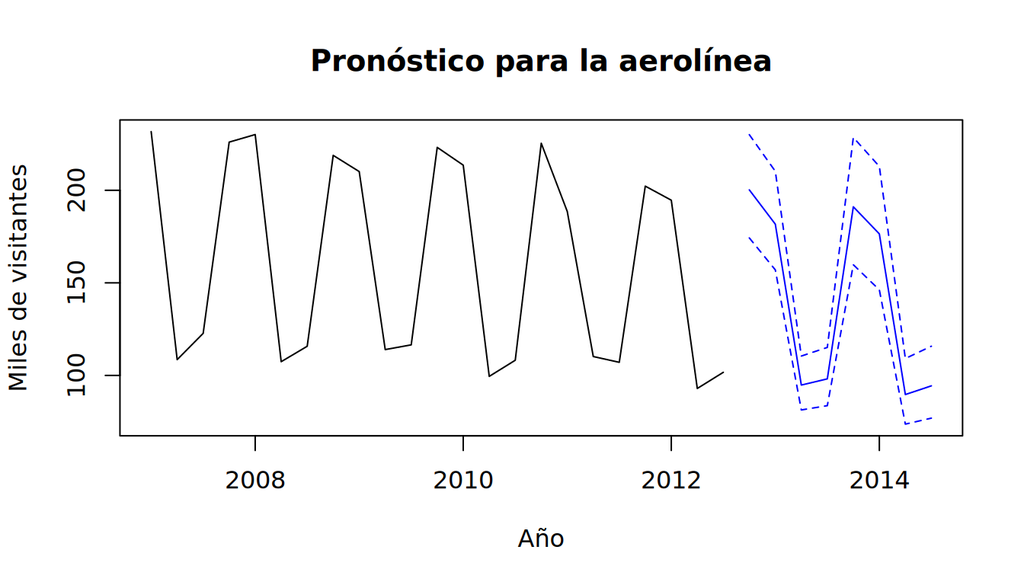

```r
puntoB <- if(retransB=="media") espB else medB
inicioB <- c(2012,4)
ts.plot(window(b,start=c(2007,1)),ts(puntoB,start=inicioB,frequency=4),
        ts(liB,start=inicioB,frequency=4),ts(lsB,start=inicioB,frequency=4),
        col=c("black","blue","blue","blue"),lty=c(1,1,2,2),
        ylab="Miles de visitantes",xlab="Año",main="Pronóstico para la aerolínea")
```

**Respuesta.** Ningún candidato cumple simultáneamente los criterios de significancia y Ljung-Box en entrenamiento; priorizamos los residuos sin evidencia de autocorrelación. Elegimos el SARIMA (0,1,1)(1,1,1)_4 porque no rechazamos la ausencia de autocorrelación en los tres contrastes de B4, aunque el AR estacional adicional no es significativo en entrenamiento ($t=-1,476$). Holt-Winters obtiene el menor RMSE general (7,609 mil), pero entre los SARIMA preferimos el segundo con la mediana, cuyo RMSE es 8,154 mil frente a 8,272 mil de la media. Después de reestimar con los 91 trimestres, los tres valores p de Ljung-Box son 0,1810; 0,1654; 0,3369, todos mayores que 0,05. Para 2013 esperamos 567,67 mil visitantes frente a 608,10 mil en 2011, una variación de -6,65 %, calculada con la suma de las medias trimestrales.

**Mensaje para la aerolínea.** Para el verano austral recomendamos planear alrededor de 200,2 mil llegadas en 2012-T4 (intervalo del 95 %: [174,3; 230,0] mil) y 181,7 mil en 2013-T1 (intervalo: [157,0; 210,3] mil). Para 2014-T3 el pronóstico es 94,4 mil con un intervalo de [76,9; 115,8] mil, por lo que recomendamos capacidad flexible. Planear con la media en lugar de la mediana aumenta la capacidad prevista y puede reducir faltantes, pero también aumenta el riesgo de plazas vacías. Las cifras representan las llegadas totales, no los pasajeros de una sola aerolínea.

# Declaración de uso de asistentes de inteligencia artificial

Se utilizó ChatGPT para revisar el enunciado y las notas del curso, organizar el repositorio, preparar la plantilla inicial y auditar y reformular el código y las interpretaciones del caso A. Se utilizó Claude (Anthropic) para entender el enunciado y apoyar la versión inicial del código y las interpretaciones del caso A. El equipo ejecutó en R los análisis de los casos A y B y revisó las salidas. También se utilizó ChatGPT para desarrollar y revisar el código, las ecuaciones, las interpretaciones del caso B, apoyar la redacción del documento técnico e incorporar el código y la interpretación del bono HEGY a partir de la documentación de uroot.

# Información de la sesión

**Código en R**